# 2020_Павловская_C#

# Потоки байтов

Ввод-вывод в файл на уровне байтов выполняется с помощью класса FileStream, который является наследником абстрактного класса Stream, определяющего набор стандартных операций с потоками. Элементы класса Stream описаны в табл. 11.5.

Таблица 11.5. Элементы класса Stream

- Элемент - Описание
- BeginRead, BeginWrite - Начать асинхронный ввод или вывод
- CanRead, CanSeek, CanWrite - Свойства, определяющие, какие операции поддерживает поток: чтение, прямой доступ и/или запись
- Close - Закрыть текущий поток и освободить связанные с ним ресурсы (сокеты, указатели на файлы и т. п.)
- EndRead, Endwrite - Ожидать завершения асинхронного ввода; закончить асинхронный вывод
- Flush - Записать данные из буфера в связанный с потоком источник данных и очистить буфер. Если для данного потока буфер не используется, то этот метод ничего не делает
- Length - Возвратить длину потока в байтах
- Position - Возвратить текущую позицию в потоке
- Read, ReadByte - Считать последовательность байтов (или один байт) из текущего потока и переместить указатель в потоке на количество считанных байтов
- Seek - Установить текущий указатель потока на заданную позицию
- SetLength - Установить длину текущего потока
- Write, WriteByte - Записать последовательность байтов (или один байт) в текущий поток и переместить указатель в потоке на количество записанных байтов

Стр.250

Класс FileStream реализует эти элементы для работы с дисковыми файлами Для определения режимов работы с файлом использукся стандартные перечисления FileMode, FileAccess и FileShare, Значения этих перечислений приведены втабл. 11.2 -11.4. В листинге 11.1 предстанлен пример работы с файлм. В примере демонстрируются чтение и запись одного байта и массива байтов, а также позиционирование в потоке.

Листинг 11.1. Пример использования потока байтов

```
using System;
using System.IO;
namespace ConsoleApplicationl
{
    class Classl
    {
        static void Main()
        {
            FileStream f = new FileStream( "test.txt", FileMode, Create, FileAccess, Readwrite );
            f.WriteByte( 100 ); // в начало файла записувается число 100
            byte[] x = new byte(10];
            for ( byte i = 0: 1 < 10; ++1 )
            {
                x(1] = (byte)( 10 - 1 );
                f.WriteByte(1); // записывается 10 чисел от 0 до 9
            }
```

```
            f.Write( x, 0, 5 ); // записывается 5 элементов массива
            byte[] y = new byte[20];
            f.Seek( 0. SeekOrigin Begin ); // текущий указатель - на начало
            f.Read( y. 0. 20 ); // чтение из файла в массив
            foreach ( byte elem in y )
                Console.Write( "* + elen);
            Console.Writeline();
            // текуший указатель - на 5-й элемент
            f.Seek(5, SeekOrigin Begin);
            int a = f.ReadByte(); // чтение 5-го элекента
            Console.Writeline( a );
            a=f.ReadByte(); // чтение 6-го элемента
            Console.WriteLine( a);
            Console.WriteLine( "Tекущая позиция в потоке" + f.Position);
            f.Close();
        }
    }
}
```

Стр.251

Результат работы программы:

```
100 0 1 2 3 4 5 6 7 8 9 10 9 8 7 6 0 0 0 0
4
5
Текущая позиция в потоке 7
```

Текущая позиция в потоке первоначально устанавливается на начало файла (для любого режима открытия, кроме Append) и сдвигается на одну позицию при записи каждого байта.Для установки желаемой позиции чтения используется метод Seek, имеющий два параметра: первый задает смещение в байтах относительно точки отсчета, задаваемой вторым. Точки отсчета задаются константами перечисления SeekOrigire начало файла - Begin, текущая позиция - Current и конец файла - End. В данном примере файл создавался в текущем каталоге. Можно указать и полный путь к файлу, при этом удобнее использовать дословные литералы, речь о которых шла в разделе «Литералы» (см. с. 30), например:

```
FileStream f = new FileStream( @"D:\C#\test.txt". FileMode.Create, FileAccess.ReadWrite );
```

В дословных литералах не требуется дублировать обратную косую черту. Операции по открытию файлов могут завершиться неудачно, например, при ошибке в имени существующего файла или при отсутствии свободного места на диске, поэтому рекомендуется всегда контролировать результаты этих операций. В случае непредвиденных ситуаций среда выполнения генерирует различные исключения, обработку которых следует предусмотреть в программе, например:

- FileNotFoundException, если файла с указанным именем в указанном каталогe не существует;
- DirectoryNotFoundException, если не существует указанный каталог;
- ArgumentException, если неверно задан режим открытия файла;
- I0Exception, если файл не открывается из-за ошибок ввода-вывода.

Возможны и другие исключительные ситуации. Удобно обрабатывать наиболее вероятные ошибки раздельно, чтобы предоставить пользователю программы в выводимом сообщении наиболее точную информацию. В приведенном далее примере отдельно перехватывается ошибка в имени файла, а затем обрабатываются все остальные возможные ошибки:

Стр.252

```
try
{
    FileStream f = new FileStream( @"d:\C#\test.tx". FileMode Open, FileAccess Read );
    ...// действия с файлом
    f.Close();
}
catch( FileNotFoundException e )
{
    Console.WriteLine( e.Message );
    Console,WriteLine( "Проверьте правильность имени файла!");
    return;
}
catch( Exception e )
{
    Console.WriteLine( "Error: " + e.Message );
    return;
}
```

При закрытии файла освобождаются все связанные с ним ресурсы, например, для файла, открытого для записи, в файл выгружается содержимое буфера. Поэтому рекомендуется всегда закрывать файлы после окончания работы, в особенности файлы, открытые для записи. Если буфер требуется выгрузить, не закрывая файл, используется метод Flush.

# Асинхронный ввод-вывод

Класс Stream (и, соответственно, FileStream) поддерживает два способа выполнения операций ввода-вывода: синхронный и асинхронный. По умолчанию файлы открываются в синхронном режиме, то есть последующие операторы выполняются только после завершения операций ввода-вывода. Для длительных файловых операций более эффективно выполнять ввод-вывод асинхронно, в отдельном потоке выполнения. Работа с потоками выполнения рассматривалась в предыдущей главе. При этом в первичном потоке можно выполнять другие операции. Для асинхронного ввода-вывода необходимо открыть файл в асинхронном режиме, для этого используется соответствующий вариант перегруженного конструктора. Асинхронная операция ввода инициируется с помощью метода BeginRead. Помимо характеристик буфера, в который выполняется ввод, в этот метод передается делегат, задающий метод, выполняемый после завершения ввода. Этот метод может инициировать обработку полученной информации, возобновить операцию чтения или выполнить любые другие действия, например, проверить успешность ввода и сообщить о его завершении. Обычно в этом методе вызывается метод EndRead, который завершает асинхронную операцию. Аналогично выполняется и асинхронный вывод. В листинге 11.2 приведен пример асипхронного чтения из файла большого объема и параллельного выполнения диалога с пользователем.

# ПРИМЕЧАНИЕ

Вообще говоря, существуют различные способы завершения асинхронных операций, и здесь демонстрируется только один из них.

Стр.253

Листинг 11.2. Асинхронный ввод

```
using System;
using System.IO;
using System.Threading;

namespace ConsoleApplication1
{
    class Demo
    {
        // диалог с пользователем
        public void UserInput()
        {
            string s;
            do
            {
                Console.WriteLine( "Введите строку, Enter для завершения" );
                s = Console.ReadLine();
            } while (s.Length != 0 ):
        }
```

```
        public void OnCompletedRead( IAsyncResult ar )
        {
            int bytes = f.EndRead( ar );
            Console.WriteLine( "Считано " + bytes );
        }
        public void AsyncRead()
        {
            f = new FileStream(
                "D:\\verybigfile"
                , FileMode.Open
                , FileAccess.Read
                , FileShare.Read
                , buf.Length
                , true
            ); // 2
            callback = new AsyncCallback( OnCompletedRead ); // 3
            f.BeginRead( buf, 0. buf Length, callback, null ); // 4
        }
```

```
        FileStream f;
        byte[] buf = new byte[66666666];
        AsyncCallback callback;
    }
    class Program
    {
        static void Main()
        {
            Demo d = new Demo();
            d.AsyncRead();
            d.User Input();
        }
    }
}
```

Стр.254

Для удобства восприятия операции чтения на файла и диалога с пользователем оформлены в отдельный класс Demo. Метод OnCompletedRead (оператор 1) должен получать один параметр стандартного типа lAsyncResult, содержащий сведения о завершении операции, которые передаются в метод EndRead. Файл открывается в асинхронном режиме, об этом говорит значение true последнего параметра конструктора (оператор 2). В операторе 3 создается экземпляр стандартного делегата AsyncCallback, который инициализируется методом OnCompletedRead. С помощью этого делегата метод OnCompletedRead передается в метод BeginRead (оператор 4), который создает отдельный поток, начинает асинхропный ввод и возвращает управление в вызвавший поток. Обратный вызов метода OnCompletedRead происходит при завершении операции ввода. При достаточно длинном файле verybigfile можно убедиться, что приглашение к вводу в методе UserInput выдается раньше, чем сообщение о завершении операции ввода из метода OnCompletedRead.

# ПРИМЕЧАНИЕ

Пример, приведенный в листииге 11.2, максимально упрощен для демонстрации методов BeginRead и EndRead, поэтому в нем нет необходимых в любой программе проверок наличия файла, успешности считывания и т. д.

# Потоки символов

Символьные потоки Streamwriter и StreamReader работают с Unicode-символами", следовательно, ими удобнее всего пользоваться для работы с файлами, предназначенными для восприятия человеком. Эти потоки являются наследниками классов TextWriter и TextReader соответственно, которые обеспечивают их большей частью функциональности. В табл, 11.6 и 11.7 приведены наиболее важные алементы этих классов. Как видите, произвольный доступ для текстовых файлов не поддерживается. Существует возможность изменить используемую кодировку с помощью объекта Sуstеm Text, Encoding.

Таблица 11.6. Наиболее важные элементы базового класса TextWriter

- Эдемент - Описание
- Close - Закрыть файл и освободить связанные с ним ресурсы, Если в пропессе записи используется буфер, он будет автоматически очищен
- Flush - Очистить все буферы для текущего файла и ааписать наконленные в них данные в место их постоянного хранения, Сам файл при этом не закрывается

Стр.255

Таблица 11.6 (продолжение)

- Элемент - Описание
- NewLine - Используется для задания последовательности символов, означающих начало новой строки. По умолчанию используется последовательность «возврат каретки» - «перевод строки» (\r\n)
- Write - Записать фрагмент текста в поток
- WriteLine - Записать строку в поток и перейти па другую строку

Таблица 11.7. Наиболее важные элементы класса TextReader

- Элемент - Описание
- Peek - Возвратить следующий символ, не изменяя позицию указателя в файле
- Read - Считать данные из входного потока
- ReadBlock - Считать из входного потока указанное пользователем количество символов и записать их в буфер, начиная с заданной позиции
- ReadLine - Считать строку из текущего потока и возвратить ее как значение типа string. Пустая строка (null) означает конец файла (EOF)
- ReadToEnd - Считать все символы до конца потока, начиная с текущей позиции, и возвратить считанные данные как одну строку типа string

Вы уже знакомы с некоторыми методами, приведенными в этих таблицах: на протяжении всей книги постоянно использовались методы чтения из текстовых потоков и записи в текстовые потоки, но не для дисковых файлов, а для консоли, которая является их частным случаем. В листинге 11.3 создается текстовый файл, в который записываются две строки. Вторая строка формируется из преобразованных численных значений переменных и поясняющего текста. Содержимое файла можно посмотреть в любом текстовом редакторе. Файл создается в том же каталоге, куда среда записывает исполняемый файл. По умолчанию это каталог …\ConsoleApplication1\bin\Debug.

Листинг 11.3. Вывод в текстовый файл

```
using System;
using System.I0:
namespace ConsoleApplicationl
{
    class Classl
    {
        static void Main()
        {
            try
            {
                StreamWriter f = new Streamwriter( "text.txt" );
                f.WriteLine( "Вывод в текстовый файл: " );
                double a = 12.234;
```

Стр.256

```
                int b = 29;
                f.WriteLine( " a = {0.6:C) b = (1.2:X)", a. b );
                f.Close();
            }
            catch( Exception e )
            {
                Console.WriteLine( "Error: " + e.Message );
                return;
            }
        }
    }
}
```

В листинге 11.4 файл, созданный в предыдущем листинге, выводится на экран.

Листинг 11.4. Чтение текстового файла

```
using System;
using System.I0;
namespace ConsoleApplication1
{
    class Classl
    {
        static void Main()
        {
            try
            {
                StreamReader f = new StreamReader( "text.txt"
                string s = f.ReadToEnd();
                Console.WriteLine(s):
                f.Close();
            }
```

```
            catch( FileNotFoundException e )
            {
                Console.WriteLine( e.Message );
                Console.WriteLine( " Проверьте правильность имени файла!");
                return;
            }
            catch( Exception e )
            {
                Console Writeline( "Error: " + e Message );
                return;
            }
        }
    }
}
```

Стр.257

В этой программе несь файл считывается на один прием с помощью метода ReadToEnd, Чаше возникает необходимость считынать файл построчно, такой пример приведен в листинге 11.5. Каждая строка при выводе предваряется номером.

Листинг 11.5. Построчное чтение текстового файла

```
using System;
using Systen.IO;
namespace ConsoleApplicationl
{
    class Classl
    {
        static void Main()
        {
```

```
            try
            {
                StreamReader f = new StreamReader( "text.txt");
                string s;
                long i = 0;
                while ( ( s = f.ReadLine() ) != null )
                    Console.WriteLine( "{0}: (1}", ++1, s );
                f.Close();
            }
            catch( FileNotFoundException e )
            {
                Console.WriteLine( e.Message );
                Console.WriteLine( "Проверьте правильность имени файла!");
                return;
            )
```

```
            catch( Exception e )
            {
                Console Writeline( "Error: " + e.Message );
                return;
            }
        }
    }
}
```

Стр.258

Листинг 11.6. Преобразования строк в числа

```
using System:
using System.IO;
namespace ConsoleApplicationl
{
    class Classl
    {
        static void Main()
        {
            try
            {
                StreamReader f = new StreamReader( "numbers.txt" );
                string s;
                const int n = 20;
                int[] a = new int[n];
                string[] buf;
```

```
                while ( ( s = f.ReadLine() ) != null )
                {
                    buf = s.Split(' ');
                    long sum = 0;
                    for ( int 1 = 0; 1 < buf.Length; ++1 )
                    {
                        a[1] = Convert.ToInt32( buf[1] );
                        sum += a[i];
                    }
                    Console.WriteLine( "{0} сумма: {1}". s. sum ):
                }
                f.Close();
            }
```

```
            catch( FileNotFoundException e )
            {
                Console.WriteLine( e.Message ):
                Console.WriteLine( " Проверьте правильность имени файла!" );
                return;
            }
            catch( Exception e )
            {
                Console.Writeline( "Error: " + e.Message );
                return;
            }
        }
    }
}
```

Реаультат работы программы:

```
1 2 4 сумма: 7
3 44 -3 6 сунма: 50
8 1 1 сумма: 10
```

Стр.259

# Двоичные потоки

Двоичные файлы хранят данные в том же виде, в котором они представлены в оперативной памяти, то есть во внутренней форме представления. Двоичные файлы применяются не для просмотра их человеком, а для использования в программах. Выходной поток Binarywriter поддерживает произвольный доступ, то есть имеется возможность выполнять запись в произвольную позицию двоичного файла. Двоичный файл открывается на основе базового потока, в качестве которого чаще всего используется поток FileStream. Входной двоичный поток содержит перегруженные методы чтения для всех простых встроенных типов данных. Основные методы двоичных потоков приведены в табл. 11.8 и 11.9.

Таблица 11.8. Наиболее важные элементы класса BinaryWriter

- Элемент - Описание
- BaseStream - Базовый поток, с которым работает объект BinaryWriter
- Close - Закрыть поток
- Flush - Очистить буфер
- Seek - Установить позицию в текущем потоке
- Write - Записать значение в текущий поток

Таблица 11.9. Наиболее важные элементы класса BinaryReader

- Элемент - Описание
- BaseStream - Базовый поток, с которым работает объект BinaryReader
- Close - Закрыть поток
- PeekChar - Возвратить следующий символ без перемещения внутреннего указателя в потоке
- Read - Считать поток байтов или символов и сохранить в массиве, передаваемом как входной параметр
- ReadXXXX - Считать из потока данные определенного типа (например, ReadBoolean, ReadByte, ReadInt32 и т. д.)

В листинге 11.7 приведен пример формирования двоичного файла. В файл записывается последовательность вещественных чисел, а затем для демонстрации произвольного доступа третье число заменяется числом 8888.

Стр.260

Листинг 11.7. Формирование двоичного файла

[output not shown]

Простите. 261-270 СТРАНИЦ ПРОСТО НЕТ

По этому заменим их другим материалом...

- 246 - Глава 11. Работа с файлами
  - 250 - Потоки байтов
  - 253 - Асинхронный ввод-вывод.
  - 255 - Потоки символов.
  - 260 - Двоичные потоки https://metanit.com/sharp/tutorial/5.6.php
  - 262 - Консольный ввод-вывод https://metanit.com/sharp/tutorial/2.15.php
  - 263 - Работа с каталогами и файлами https://metanit.com/sharp/tutorial/5.2.php
  - 267 - Сохранение объектов (сериализация) https://metanit.com/sharp/tutorial/6.1.php
  - 270 - Рекомендации по программированию (Я тоже не всесилен...) 272 - Глава 12. Сборки, библиотеки, атрибуты, директивы

Поток определяется как последовательность байтов и не зависит от конкретного устройства, с которым производится обмен. Классы библиотеки позволяют работать с потоками в различных режимах и на различных уровнях: на уровне двоичного представления данных, байтов и текста, Двоичные и байтовые потоки хранят данные во внутреннем представлении, текстовые - в кодировке Unicode. Поток можно открыть в синхронном или асинхронном режиме для чтения, записи или добавления. Доступ к файлам может быть последовательным и произвольным. Текстовые файлы позволяют выполнять только последовательный доступ, в двоичных и байтовых потоках можно использовать оба метода. Прямой доступ в сочетании с отсутствием преобразований обеспечивает высокую скорость обмена. Методы форматированного ввода для значений арифметических типов в С# не поддерживаются. Для преобразования из символьного в числовое представление используются методы класса Convert или метод Parse. Форматированный вывод выполняется с помощью перегруженного метода ToString, результат выполнения которого передается в методы текстовых файлов. Рекомендуется всегда проверять успешность открытия существующего файла, перехватывать исключения, возникающие при преобразовании значений арифметических типов, и явным образом закрывать файл, в который выполнялась запись. Длительные операции с файлами более эффективно выполнять в асинхронном режиме. Для сохранения объектов (сериализации) используется атрибут $[Serializable]$. Объекты можно сохранять в одном из двух форматов: двоичном или SOAP (в виде XML-файла).

Стр. 271

# Глава 12 Сборки, библиотеки, атрибуты, директивы

Все наши предыдущие приложения состояли из одного физического файла. Для больших проектов это неудобно и чаще всего невозможно, да и в других случаях бывает удобнее поместить связанные между собой типы в библиотеку и использовать их по мере необходимости. В этой главе мы рассмотрим вопросы создания и использования библиотек, способы получения и подготовки информации о типах, пространства имен и препроцессор. Эти сведения необходимы для успешной разработки реальных программ.

# Сборки

В результате компиляции в среде .NET создается сборка - файл с расширением ехе или dil, который содержит код на промежуточном языке, метаданные типов, манифест и ресурсы (рис. 12.1). Понятие сборки было введено в главе 1 (см. с. 9), а сейчас мы рассмотрим ее составные части более подробно.

- Манифест
- Метаданые
- Код на языке IL
- Рессурсы (Не обязательно)

Рис. 12.1. Сборка, состоящая из одного файла

Стр. 272

Промежymочный язык (Intermediate Language, IL) не содержит инструкций, зависящих от операционной системы и тина компьютера, что обеспечивает две основные возможности:

- выполнение приложения на любом тине компьютера, для которого существует среда выполнения CLR;
- повторное использование кода, написанного на любом .NET-совместимом языке.

IL-код можно просмотреть с помощью дизассемблера ILDasm.exe, который находится в панке …\SDK\bin\ каталога размещения Visual Studio.NET , После запуска ILDasm можно открыть любой файл среды .NET с расширением ехе или dil с помощью команды File » Open. В окне программы откроется список всех элементов сборки, сведения о каждом можно получить двойным щелчком. При этом открывается окно, в котором для методов выводится доступный для восприятия дизассемблированный код. Метаданные типов - это сведения о типах, используемых в сборке. Компилятор создает метаданные автоматически. В них содержится информация о каждом типе, имеющемся в программе, и о каждом его элементе. Например, для каждого класса описываются все его поля, методы, свойства, события, базовые классы и интерфейсы. Среда выполнения использует метаданные для поиска определений типов и их элементов в сборке, для создания экземпляров объектов, проверки вызова методов и т. д. Компилятор, редактор кода и средства отладки также широко используют метаданные, например, для вывода подсказок и диагностических сообщений. Манифест - это набор метаданных о самой сборке, включая информацию обо всех файлах, входящих в состав сборки, версии сборки, а также сведения обо всех внешних сборках, на которые она ссылается. Манифест создается компилятором автоматически, программист может дополнять его собственными атрибутами.

Чаще всего сборка состоит из единственного файла, однако она может включать и несколько физических файлов (модулей). В этом случае манифест либо включается в состав одного из файлов, либо содержится в отдельном файле. Многофайловые сборки используются для ускорения загрузки приложения - это имеет смысл для сборок большого объема, работа с которыми производится удаленно. На логическом уровне сборка представляет собой совокупность взаимосвязанных типов - классов, интерфейсов, структур, перечислений, делегатов и ресурсов. Библиотека .NET представляет собой совокупность сборок, которую используют приложения. Точно так же можно создавать и собственные сборки, которые можно будет задействовать либо в рамках одного приложения (частные сборки). либо совместно различными приложениями (открытые сборки). По умолчанию все сборки являются частными.

Стр. 273

# Манифест сборки содержит:

- идентификатор версии;
- список всех внутренних модулей сборки;
- список внешних сборок, необходимых для нормального выполнения сборки;
- информацию о естественном языке, используемом в сборке (например, русском);
- «сильное» имя (strong name) - специальный вариант имени сборки, используемый для открытых сборок;
- необязательную информацию, связанную с безопасностью;
- необязательную информацию, связанную с хранением ресурсов внутри сборки (подробнее о форматах ресурсов .NET см. [27]).

Идентификатор версии относится ко всем элементам сборки. Он позволяет избегать конфликтов имен и поддерживать одновременное существование и использование различных версий одних и тех же сборок. Идентификатор версии состоит из двух частей: информационной версии в виде текстовой строки и версии совместимости в виде четырех чисел, разделенных точками:

- основной номер версии (major version);
- дополнительный номер версии (minor version);
- номер сборки (build number);
- номер ревизии (revision number).

Среда выполнения применяет идентификатор версий для определения того, какие из открытых сборок совместимы с требованиями клиента. Например, если клиент запрашивает сборку 3.1.0.0, а присутствует только версия 3.4.0.0, сборка не будет опознана как подходящая, поскольку считается, что в дополнительных версиях могут произойти изменения в типах и их элементах. Разные номера ревизии допускают, но не гарантируют совместимость. Номер сборки на совместимость не влияет, так как чаще всего он изменяется при установке заплатки, или патча (patch).

Идентификатор версии формируется автоматически, но при желании можно задать его вручную с помощью атрибута $[$AssemblyVersion$]$ , который рассматривается далее на с. 285. Информация о безопасности позволяет определить, предоставить ли клиенту доступ к запрашиваемым элементам сборки. В манифесте сборки определены ограничения системы безонасности. Ресурсы представляют собой, например, файлы изображений, помещаемых на форму, текстовые строки, значки приложения и т. д. Хранение ресурсов внутри сборки обеспечивает их защиту и упрощает развертывание приложения. Среда Visual Studio.NET предоставляет возможности автоматического внедрения ресурсов в сборку. Открытые и частные сборки различаются по способам размещения на компьютере пользователя, именованию и политике версий. Частные сборки должны находиться в каталоге приложения, использующего сборку, или в его подкаталогах. Открытые сборки размещаются в специальном каталоге, который пазывается глобальным кэшем сборок (Global Assembly Cache, GAC), Для идентификации открытой сборки используется уже упоминавшееся сильное имя (strong name). которое должно быть уникальным.

Стр. 274

# Создание библиотеки

[figure not shown]

Рис. 12.2. Создание библиотеки

Текст модуля приведен в листинге 12.1. По сравнению с модулем из главы 8 в него добавлены спецификаторы доступа public для всех трех классов, входящих в библиотеку.

Листинг 12.1. Библиотека монстров

```
namespace MonsterLib
{
    using System;
    public abstract class Spirit { public abstract void Passport(); }

    public class Monster : Spirit
    {
        public Monster()
        {
            this.health = 100;
            this.ammo = 100 ;
            this.name = "Noname";
        }
    }
```

Стр. 275

```
    public Monster( string name ) : this() { this.name - name; }
    public Monster( int health, int ammo, string name )
    {
        this.health = health;
        this.ammo = ammo;
        this.name = name;
    }
    public int Health
    {
        get { return health; }
        set
        {
            if ( value > 0 ) health = value:
            else health = 0;
        }
    }
```

```
    public int Ammo
    {
        get { return ammo; }
        set
        {
            if ( value > ( ) ammo = value;
            else ammo = 0 ;
        }
    }
    public string Name { get { return name; } }
    override public void Passport()
    { Console.WriteLine( "Monster (0} \t health = {1} ammo = {2}". name, health, ammo ); }
    string name;
    int health, ammo;
}
```

Стр. 276

```
    public class Daemon : Monster
    {
        public Daemon() { brain = 1; }
        public Daemon( string name, int brain ) : base( name )
        { this.brain = brain; }
        public Daemon( int health, int ammo, string name, int brain ) : base( health, ammo, name )
        { this. brain = brain; }
        override public void Passport()
        { Console. WriteLine( "Daemon (0) \t health = (1) ammo = (2) brain = (3)" Name, Health, Ammo, brain );}
        public void Think()
        {
            Console.Write( Name + " is" for ( int 1 = 0; 1 < brain; *+1 );
            Console.Write( " thinking" );
            Console. WriteLine("...");
        }
        int brain ;
    }
}
```

Стр. 277

Скомпилировав библиотеку, вы обнаружите файл MonsterLib.dil в каталогах …\bin\ Debug и …\obj\Debug. Открыв файл MonsterLib.dll с помощью программы ILDasm.exe, можно получить полную информацию о созданной библиотеке (рис. 12.3).

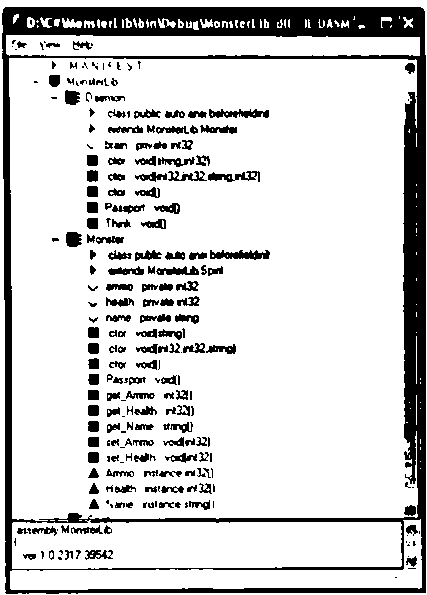

Рис. 12.3. Просмотр библиотеки с помощью дизассемблера ILDasm.exe

# Использование библиотеки

Любая библиотека - это сервер, предоставляющий свои ресурсы клиентам. Создадим клиентское приложение, выполняющее те же функции, что и приложение из раздела «Виртуальные методы» (см. с. 178), но с использованием библиотеки MonsterLib.dil. Для того чтобы компилятор мог се обнаружить, необходимо после создания проекта (как обычно, это - консольное приложение) подключить ссылку на библиотеку с помощью команды Project » Add Reference (Добавить ссылку). Для поиска каталога, содержащего библиотеку, следует использовать кнопку Browse. После подключения библиотеки можно пользоваться ее открытыми элементами таким же образом, как если бы они были описаны в том же модуле. Текст приложения приведен в листинге 12.2.

Стр. 278

Листинг 12.2. Клиентское приложение

```
using System;
namespace ConsoleApplicationl
{
    using MonsterLib;
    class Classl
    {
        static void Main()
        {
            const int n = 3;
            Monster[] stado = new Monster[n];
            stado[0] = new Monster( "Monia" );
            stado[1] = new Monster( "Monk" );
            stado[2] = new Daemon ( "Dimon", 3 );
            foreach ( Monster elem in stado ) elem.Passport();

            for ( int i = 0; i < n; ++1 ) stado[i] Ammo = 0;
            Console.WriteLine();

            foreach ( Monster elem in stado ) elem.Passport():
        }
    }
}
```

Результаты работы программы совпадают с полученными в листинге 8.3. Анализ каталога …\bin\Debug показывает, что среда создала в нем копию библиотеки MonsterLib.dll, то есть поместила библиотеку в тот же каталог, что и исполняемый файл. Если скопировать эти два файла в другое место, программа не потеряет своей работоспособности - главное, чтобы оба файла находились в одном каталоге. Допускается также, чтобы частные сборки паходились в подкаталогах основного каталога приложения.

# ПРИМЕЧАНИЕ

Преимущество .NET состоит в том, что благодаря стандартным соглашениям можно использовать библиотски независимо от языка, на котором они были написаны. Таким образом, можно было бы написать клиентское приложение, например, на языке VB.NET.

# Рефлексия

Рефлексия - это получение информации о типах во время выполнения программы. Например, можно получить список всех классов и интерфейсов сборки, список элементов каждого из классов, список параметров каждого метода и т. д. Вся информация берется из метаданных сборки. Для использования рефлексии необходимы класс System. Type и типы пространства имен System.Reflection. В классе Туре описаны методы, которые позволяют получить информацию о типах. В пространстве имен System. Reflection описаны типы, поддерживающие Type, а также классы, которые служат для организации позднего связывания и динамической загрузки сборок. Наиболее важные свойства и методы класса Туре приведены в табл. 12.1.

Стр. 279

Таблица 12.1. Элементы класса Туре

- Элемент - Описание -
- IsAbstract, IsArray, IsNestedPublic, IsClass, IsNestedPrivate, IsCOMObject, IsEnum, IsInterface, IsPrimitive, IsSealed, IsValueType
  - Свойства, позволяющие получить соответствующие характеристики конкретного типа в программе (например, является ли он абстрактным, является ли он массивом, классом и т. п.). Приведены не все свойства
- GetConstructors, GetEvents, GetFields, GetInterfaces. GetMethods, GetMembers, GetNestedTypes, GetProperties
  - Методы, возвращающие массив с набором соответствующих элементов (конструкторов, событий, полей и т. п.). Возвращаемое значение соответствует имени метода, например, GetFields возвращает массив типа FieldInfo, GetMethods - массив типа MethodInfo. Для каждого из методов есть парный ему (без символа s в конце имени), который предназначен для работы с одним заданным в параметре элементом (например, GetMethod и GetMethods)
- FindMembers - Метод возвращает массив типа MemberInfo на основе заданных критериев поиска
- GetType - Метод возвращает объект типа Туре по имени, заданному в виде строки
- InvokeMember - Метод используется для позднего связывания заданного элемента

Воспользоваться этими методами можно после создания экземпляра класса Туре. Поскольку это абстрактный класс, обычный способ создания объектов с помощью операции new неприменим, зато существуют три других способа:

1.В базовом классе object описан метод GetType, которым можно воспользоваться для любого объекта, поскольку он наследуется. Метод возвращает объект типа Туре, например:

```
Monster X = new Monster();
Type t = X.GetType();
```

2.В классе Туре описан статический метод GetType с одним параметром строкового типа, на место которого требуется передать имя класса (тица), например:

```
Type t - Type, GetType( "Monster" )
```

1. Операция typeof возвращает объект класса Tурe для типа, заданного в качестве параметра, например:

   Type t = typeof( Monster );

Стр. 280

При использовании второго и третьего способов создавать экземпляр исследуемого класса нет необходимости. Как видно из табл. 12.1, многие методы класса Туре возвращают экземпляры стандартных классов (например, MemberInfo). Эти классы описаны в пространстве имен System.Reflection. Наиболее важные из этих классов перечислены в табл. 12.2.

Таблица 12.2. Некоторые классы пространства имен System.Reflection

- Тип - Описание -
- Assembly - Содержит методы для получения информации о сборке, а также для загрузки сборки и выполнения с ней различных операций
- AssemblyName - Позволяет получать информацию о сборке (имя, версия, совместимость, естественный язык и т. п.)
- EventInfo - Хранит информацию о событии
- FieldInfo - Хранит информацию о поле
- Member Info - Абстрактный базовый класс, определяющий общие элементы для классов EventInfo, FieldInfo, MethodInfo и PropertyInfo
- MethodInfo - Хранит информацию о методе
- Module - Позволяет обратиться к модулю в многофайловой сборке
- ParameterInfo - Хранит информацию о параметре
- PropertyInfo - Хранит информацию о свойстве

В листинге 12.3 приведены примеры использования рассмотренных методов и классов для получения информации о классах библиотеки из листинга 12.1.

Листинг 12.3. Получение информации о классах

```
using System;
using System Reflection;
namespace ConsoleApplicationl
{
    using MonsterLib;
    {
        class Classl
        {
            static void Info( Type t )
            {
```

```
                Console Writeline( "Класс " + t.FullName);
                if ( t.IsAbstract ) Console.Writeline( "абстрактный");
                if ( t.IsClass) Console.Writeline( "обычный");
                if ( t. IsEnum) Console.Writeline( "перечисление" );

                Console.Writeline( "базовый класс " + t BaseType );
                MethodInfo[] met = t.GetMethods():
                foreach ( MethodInfo m in met ) Console Writeline( m );
                Console.Writeline();

                PropertyInfo[] prs = t.GetProperties();
                foreach ( PropertyInfo p in prs ) Console.WriteLine( p );
                Console.WriteLine();
            }
```

Стр. 281

```
            static void Main()
            {
                Type t = typeof( Spirit);
                Info(t);
                t = typeof( Monster);
                Info(t);
                t = typeof( Daemon );
                Info( t );
            }
        }
    }
```

Результат работы программы:

```
=====Класс MonsterLib. Spirit
абстрактный
обычный
базовый класс System.Object
Void Passport()
Int32 GetHashCode()
Boolean Equals(System Object)
System.String ToString()
System.Type GetType()
```

```
===== Класс MonsterLib.Monster
обычный
базовый класс MonsterLib.Spirit
Void Passport()
Int32 GetHashCode()
Boolean Equals(System.Object)
System.String ToString()
Int32 get_Health()
Void set_Health(Int32)
Int_32 get_Ammo()
void set_Ammo(Int32)
System.String get_Name()
System.Type GetType()
Int32 Health
Int32 Ammo
System.String Name
```

Стр. 282

```
========== Класс MonsterLib.Daemon
обычный
базовый класс MonsterLib.Monster
Void Passport()
Int32 GetHashCode()
Boolean Equals(System.Object)
System.String ToString()
Void Think()
Int32 get_Health()
Void set_Health(Int32)
Int32 get_Ammo()
Void set_Ammo( Int32)
System.String get_Name()
System.Type GetType()
Int32 Health
Int32 Ammo
System.String Name
```

Можно продолжить исследования дальше, например, получить параметры и возвращаемое значение каждого метода. Думаю, что принцип вам уже ясен. Напомню, что вся эта информация берется из метаданных сборки.

# Атрибуты

Атрибуты - это дополнительные сведения об элементах программы (классах, методах, параметрах и т. д.). С помощью атрибутов можно добавлять информацию в метаданные сборки и затем извлекать ее во время выполнения программы. Атрибут является специальным видом класса и происходит от базового класса System.Attribute. Атрибуты делятся на стандартные и пользовательские. В библиотеке .NET предусмотрено множество стандартных атрибутов, которые можно использовать в программах. Если всего разнообразия стандартных атрибутов не хватит, чтобы удовлетворить прихотливые требования программиста, он может описать собственные классы атрибутов, после чего применять их точно так же, как стандартные. При использовании (спецификации) атрибутов они задаются в секции атрибутов, располагаемой непосредственно перед элементом, для описания которого они предназначены. Секция заключается в квадратные скобки и может содержать несколько атрибутов, перечисляемых через запятую. Порядок следования атрибутов произвольный.

Для каждого атрибута задаются имя, а также необязательные параметры и тип элемента сборки, к которому относится атрибут, Простейший пример атрибута:

```
[Serializable]
сlass Monster
{
    ...
    [NonSerialized]
    string name;
    int health, ammo;
}
```

Стр. 283

Таблица 12.3. Типы элемента сборки, задаваемые для атрибутов

- Ключевое слово - Описание
- assembly - Атрибут относится ко всей сборке
- field - Атрибут относится к полю
- event - Атрибут относится к событию
- method - Атрибут относится к методу
- param - Атрибут относится к параметрам метода
- property - Атрибут относится к свойству
- return - Атрибут относится к возвращаемому значению
- type - Атрибут относится к классу или структурс

Пусть, например, перед методом описан гипотетический атрибут АВС:

```
[ABC]
public void Do(){...}
```

По умолчанию он относится к методу. Чтобы указать, что атрибут относится не к методу, а к его возвращаемому значению, следует написать:

```
[return: ABC]
public void Do() {...}
```

Атрибут может иметь параметры, Они записываются в круглых скобках через запятую после имени атрибута и бывают позиционными и именованными. Именованный параметр указывается в форме имя - значение, для позиционного просто задается значение. Например, для использованного в следующем фрагменте кода атрибута CLSCompl1ant задан позиционный параметр true.

Стр. 284

Атрибуты, относящиеся к сборке, должны располагаться пепосредственно после директив using, например:

```
using System;
[assembly: CLSCompliant(true)]
namespace ConsoleApplicationl
{
    ...
```

Атрибут $[CLSCompliant]$ определяет, удовлетворяет программный код соглашениям CLS (Common Language Specification) или нет. Стандартные атрибуты, как и другие типы классов, имеют набор конструкторов, которые определяют, каким образом использовать (специфицировать) атрибут. Фактически, при использовании атрибута указывается наиболее подходящий конструктор, а величины, не указанные в конструкторе, задаются через именованные параметры в конце списка параметров. Стандартный атрибут $[STAThread]$, старательно удаленный из всех листингов в этой книге, относится к методу, перед которым он записан. Он имеет значение только для приложений, использующих модель СОМ, и задает модель потоков в рамках модели СОМ. Пример применения еще одного стандартного атрибута, $[Conditional]$, приведен далее в разделе «Директивы препроцессора».

Атрибуты уровня сборки хранятся в файле Assemblyinfo.cs, автоматически создаваемом средой для любого проекта. Для явного задания номера версии сборки можно записать атрибут $[AssemblyVersion]$, например:

```
[assembly; AssemblyVersion("1.0.0.0")]
```

Создание пользовательских атрибутов выходит за рамки темы этого учебника. Интересующиеся могут обратиться к книге $[27]$.

# Пространство имен

Пространство имен - это контейнер для типов, определяющий область их видимости. Пространства имен предотвращают конфликты имен и используются для двух взаимосвязанных целей:

- логического группирования элементов программы, расположенных в различных физических файлах;
- группирования имен, предоставляемых сборкой в пользование другим модулям.

Во всех программах, созданных ранее, использовалось пространство имен, создаваемое по умолчанию. Реальные программы чаще всего разрабатываются группой программистов, каждый из которых работает со своим набором физических файлов (единиц компиляции), хранящих элементы создаваемого приложения. Если в разных файлах описать пространства имен с одним и тем же именем, то при построении приложения, состоящего из этих файлов, будет скомпоновано единое пространство имен.

Стр. 285

Пространства имен могут быть иложенными, например:

```
namespace State
{
    namespace City
    {...}
}
```

Такое объявление апалогично следующему:

```
namespace State.City
{...}
```

Вложенные пространства имен, как вы наверняка успели заметить, широко применяются в библиотеке ,NET. Существует три способа использования типа, определенного в каком-либо пространстве имен:

1.Использовать полностью квалифицированное имя. Например, в пространстве имен System.Runtime.Serialization.Formatters.Binary описан класс BinaryFormatter. Создание объекта этого класса с помощью квалифицированного имени выглядит так:

```
System.Runtime.Serialization.Formatters.Binary.BinaryFormatter bf =
    new System.Runtime.Serialization.Formatters.Binary.BinaryFormatter()
;
```

2.Использовать директиву using, с помощью которой импортируются все имена из заданного пространства. В этом случае предыдущий пример примет вид

```
using System.Runtime.Serialization.Formatters.Binary;
...
BinaryFormatter bf = new BinaryFormatter();
```

# ВНИМАНИЕ

Директива using должна располагаться вне или внутри пространства имеи, но до любых описаний типов.

3.Использовать псевдоним типа. Это делается с помощью второй формы директивы using:

```
using Binf = System.Runtime.Serialization.Formatters.Binary.BinaryFormatter;
...
BinF bf = new BinF();
```

Первый способ применяется при однократном использовании имени типа из «неглубоко» вложенных пространсти имен, второй в больнинстве остальных случаев, что мы и делали во всех примерах, а третий можно рекомендовать при многократном использовании длинного имени типа.

Стр. 286

В версию языка С# 2.0 введена возможность применять псевдоним пространства имен с помощью операции ::, например:

```
using SIO = System.IO; // псевдоним пространства имен
using MIO = MyLibrary.I0; // псевдоним пространства имен
class Program
{
    static void Main()
    {
        SIO::Stream s = new MIO::EmptyStream(); // использование псевдонимов
        ...
    }
}
```

Использование псевдонима для пространства имен гарантирует, что последующие подключения других пространств имен к этой сборке не повлияют на существующие определения. Слева от операции : : можно указать идентификатор global. Он гарантирует, что поиск идентификатора, расположенного справа от операции, будет выполняться только в глобальном пространстве имен. Цель использования этого идентификатора та же: не допустить изменений существующих определений при разработке следующих версий программы, в которых в нее могут быть добавлены новые пространства имен, содержащие элементы с такими же именами. Таким образом, сборки обеспечивают физическое группирование типов, а пространства имен - логическое. В мире сетевого программирования, когда программисту доступны десятки тысяч классов, простраиства имен совершенно необходимы как для классификации и поиска, так и для предотвращения конфликтов имен типов.

# Директивы препроцессора

Препроцессором в языке С++ пазывается предварительный этап компиляции, формирующий окончательный вариант текста программы. В языке С#, потомке С++, препроцессор практически отсутствует, но некоторые директивы сохранились, Назначение директив - исключать из процесса компиляции фрагменты кода при вынолиении определенных условий, выводить сообщения об ошибках и предупреждения, а также структурировать код программы. Каждая директива располагается на отдельной строке и не заканчивается точкой с занитой, в отличие от операторон языка. В одной строке с директивой может располагаться только комментарий вида //, Перечень и краткое описание директив приведены в табл. 12.4. Рассмотрим более подробно применение директин условной компиляции, Они испольнуются для того, чтобы исключить компиляцию отдельных частей программы, Это бывает полезно при отладке или, например, при поддержке нескольких версий программы для различных платформ.

Стр. 287

Таблица 12.4. Директивы препроцессора

- Наименование - Описание -
- #define, #undef - Определение (например, #define DEBUG) и отмена определения (#undef DEBUG) символьной константы, которая используется директивами условной компицяции. Директывы размещаются до первой лексемы единицы компиляции. Допускается повторное определение одной и той же константы.
- #if, #elif, #else, #endif - Директивы условной компиляции, Код, находищийся в области их действия, комнилируется или пропусклется и зависимости от тео, была ли ранее определена символьная константа (см. далее)
- #line - Задание номера строки и имени файла, о котором выдаются сообщения. позникающие при компиляции (например, #line 200 "ku_ku.txt") При этом в диагностических сообщениях компилятора имя компилирусмого файла заменяется указанным, а строки пумеруются, начиная с заданного первым параметром помера
- Наименование - Описание -
- #error, #warning - Вывод при компиляции сообщения, указанного в строке директивы. После выполнения директивы lerror компиляция прекращается (например, #error Дальше компилировать нельзя). После выполнения директивы #warning компиляция продолжается.
- #region, #endregion - Определение фрагмента кода, который можно будет свернуть или развернуть средствами редактора кода. Фрагмент располагается между этими директивами
- #pragma - Введена в версии C# 2.0. Позволяет отключить (#pragma warning disable) или восcтановить (#pragma warning restore ) выдачу всеx или перечисленных в директиве предупреждений компилятора

Формат директив:

```
#if константное выражение
...
[ #elif константное выражение
...]
[ #elif константное выражение
...]
[ #else
...]
#endif
```

Натуре находитси много вещей, неизьяснимых даже для общирного ума», Н. В. Гоголь

Стр. 288

Пример применения директив приведен в листинге 12.4.

Листинг 12.4. Применение директив условной компиляции

```
// #define VAR1
// #define VAR2
using System;
namespace ConsoleApplicationl
{
    class Class1
    {
        #if VAR1
        static void F(){ Console.WriteLine( "Вариант 1" ); }
        #elif VAR2
        static void F(){ Console.WriteLine( "Вариант 2" ): }
        #else
        static void F(){ Console.WriteLine( "Основной вариант" ); }
        #endif
        static void Main(){F();}
    }
}
```

В зависимости от того, определение какой символьной константы раскомменти- ровать, в компиляции будет участвовать один из трех методов F. Директива #define применяется не только в сочетании с директивами условной компиляции. Можно применять ее вместе со стандартным атрибутом Conditional для условного управления выполнением методов. Метод будет выполняться, если константа определена. Пример приведен в листинге 12.5. Обратите впима- ние на то, что для применения атрибута необходимо подключить пространство имен System. Diagnostics.

Листинг 12.5. Использование атрибута Conditional

```
// #define VAR1
#define VAR2
using System;
using System.Diagnostics:
namespace ConsoleApplicationl
{
    class Class1
    {
        [Conditional ("VAR1")]
        static void A(){ Console.WriteLine( "Выполняется метод A" ); }
        [Conditional ("VAR2")]
        Листинг 12.5 (продолжение)
        static void B(){ Console.WriteLine( "Выполняется метод B" ); }
        static void Main() { A(); B(); }
    }
}
```

В методе Main записаны вызовы обоих методов, однако в данном случае будет выполнен только метод В, поскольку символьная константа VAR1 не определена.

Стр. 289

# Рекомендации по программированию

В этой главе приведено краткое введение в средства, использующиеся при профессиональной разработке программ: библиотеки, рефлексия типов, атрибуты. пространства имен и директивы препроцессора. Для реального использования этих возможностей в программах необходимо изучать документацию и дополнительную литературу, например $[20]$, $[21]$, $[26]$, $[27]$, $[30]$.

Стр. 290

# Глава 13 Структуры данных, коллекции и классы-прототипы

В этой главе приводится обзор основных структур данных, используемых в программировании, и их реализация в библиотеке .NET в виде коллекций. Кроме того, описываются средства, добавленные в версию С# 2.0, - классы-прототипы (generics), частичные типы (partial types) и обнуляемые типы (nullable types). Остальные средства, появившиеся в версии 2.0, были рассмотрены ранее. Например, итераторы - в главе 9, анонимные методы - в главе 10.

# Абстрактные структуры данных

Любая программа предназначена для обработки данных, от способа организации которых зависит ее алгоритм. Для разных задач необходимы различные способы хранения и обработки данных, поэтому выбор структур данных должен предшествовать созданию алгоритмов и основываться на требованиях к функциональности и быстродействию программы. Наиболее часто в программах используются следующие структуры дапных: массив, список, стек, очередь, бинарное дерево, хеш-таблица, граф и множество. Далее даны краткие характеристики каждой из этих структур. Массие - это конечная совокупность однотинных величин. Массив занимает непрерывную область памяти и предоставляет прямой, или произвольный, доступ к своим элементам по индексу. Память под массив выделяется до начала работы с ним и впоследствии не изменяется.

Стр. 291

В списке каждый элемент связан со следующим и, возможно, с предыдущим. В первом случае список называется односвязным, во втором - двусвязным. Также применяются термины однонаправленный и двунаправленный. Если последний элемент связать указателем с первым, получается кольцевой список. Количество элементов в списке может изменяться в процессе работы программы. Каждый элемент списка содержит ключ, идентифицирующий этот элемент. Ключ обычно бывает либо целым числом, либо строкой и является частью данных, хранящихся в каждом элементе списка. В качестве ключа в процессе работы со списком могут выступать разные части данных. Например, если создается список из записей, содержащих фамилию, год рождения, стаж работы и пол, любая часть записи может выступать в качестве ключа: при упорядочивании списка по алфавиту ключом будет фамилия, а при поиске, например, ветеранов труда ключом можно сделать стаж. Ключи разных элементов списка могут совпадать. Над списками можно выполнять следующие операции:

- добавление элемента в конец списка;
- чтение элемента с заданным ключом:
- вставка элемента в заданное место списка;
- удаление элемента с заданным ключом;
- упорядочивание списка по ключу.

Список не обеспечивает произвольный доступ к элементу, поэтому при выполнении операций чтения, вставки и удаления выполняется последовательный перебор элементов, пока не будет найден элемент с заданным ключом. Для списков большого объема перебор элементов может занимать значительное время, поскольку среднее время поиска элемента пропорционально количеству элементов в списке.

Стек - это частный случай однонаправленного списка, добавление элементов в который и выборка из которого выполняются с одного конца, называемого вершиной стека. Другие операции со стеком не определены. При выборке элемент исключается из стека. Говорят, что стек реализует принцип обслуживания LIFO (Last In - First Out, последним пришел - первым ушел). Стек проще всеro представить себе как закрытую с одного конца узкую трубу, в которую бросают мячики. Достать первый брошенный мячик можно только после того, как вынуты все остальные. Стеки широко применяются в системном программном обеспечении, компиляторах, в различных рекурсивных алгоритмах.

Очередь - это частный случай однонаправленного списка, добавление элементов в который выполияется в один конец, а выборка - из другого конца. Другие операции с очередью не определены, При выборке элемент исключается из очереди. Говорят, что очередь реализует принцип обслуживания FIFO (First In - First Out, первым пришел - первым ушел). Очередь проще всего представить себе, постояв в ней час-другой. В программировании очереди применяются, например, в моделировании, диспетчеризации задач операционной системой, буферизованном вводе-выводе.

Бинарное дерево - это динамическая структура данных, состоящая из узлов, каждый из которых содержит номимо данных не более двух ссылок на различные бинарные поддеревья. На каждый узел имеется ровно одна ссылка. Начальный узел называется корнем дерева. Пример бинарного дерева приведен на рис. 13.1 (корень обычио изображается сверху). Узел, не имеющий поддеревьев, называется листом. Исхолящие узлы называются предками, входящие - потомками. Высота дерева определяется количеством уровней, на которых располагаются его узлы.

Стр. 292

- 10 [x][x]
  - 6 [x][x]
    - 1 [x][x]
    - 8 [x][x]
  - 25 [x][x]
    - 30 [x][x]
    - 20 [x][x]
      - 21 [x][x]

Рис. 13.1. Пример бинарного дерева поиска

Если дерево организовано таким образом, что для каждого узла все ключи его левого поддерева меньше ключа этого узла, а все ключи его правого поддерева - больше, оно называется деревом поиска. Одинаковые ключи не допускаются. В дереве поиска можно пайти элемент по ключу, двигаясь от корня и переходя на левое или правое поддерево в зависимости от значения ключа в каждом узле. Такой поиск гораздо эффективнее поиска по списку, поскольку время поиска определяется высотой дерева, а она пропорциональна двоичному логарифму количества узлов, Впрочем, скорость поиска в значительной степени зависит от порядка формирования дерева: если на вход подается упорядоченная или почти унорядоченная последовательность ключей, дерево вырождается в список. Для ускорения поиска применяется процедура балансировки дерева, формирующая дерево, поддеревья которого различаются не более чем на один эдемент. Бинарные деревья применяются для эффективного поиска и сортировки данных. Хеш-таблица, ассоциативный массив, или словарь - это массив, доступ к элементам которого осуществляется не по померу, а по некоторому ключу. Можно сказать, что это таблица, состоящая из пар «ключ -значение» (табл. 13.1). Хеш- таблица эффективно реализует операцию поиска значения по ключу. При этом ключ преобразуется в число (хеш-код), которое используется для быстрого нахождения нужного значения в хеш-таблице.

Стр. 293

Таблица 13.1. Пример хеш-таблицы

- Ключ - Значение -
- boy - мальчик
- girl - девочка
- dog - собачка

Преобразование выполняется с помощью хеш-функции, или функции расстановки. Эта функция обычно производит какие-либо преобразования внутреннего представления ключа, например, вычисляет среднее арифметическое кодов составляющих его символов (английское слово «hash» означает перемалывать, перемешивать). Если хеш-функция распределяет совокупность возможных ключей равномерно по множеству индексов массива, то доступ к элементу по ключу выполняется почти так же быстро, как в массиве. Если хеш-функция генерирует для разных ключей одинаковые хеш-коды, время поиска возрастает и становится сравнимым со временем поиска в списке.

# ПРИМЕЧАНИЕ

Грубый пример хеш-функции: когда мы обращаемся к англо-русскому словарю, мы можем использовать в качестве хеш-кода первую букву английского слова (ключа). Открыв словарь на странице, с которой начинаются слова на эту букву, выполняем последовательный поиск ключа в списке.

Смысл хеш-функции состоит в том, чтоб отобразить более широкое множество ключей в более узкое множество индексов. При этом неизбежно возникают так называемые коллизии, когда хеш-функция формирует для двух разных элементов один и тот же хеш-код. В разных реализациях хеш-таблиц используются различные стратегии борьбы с коллизиями. Граф - это совокупность узлов и ребер, соединяющих различные узлы. Например, можно представить себе карту автомобильных дорог как граф с городами в качестве узлов и шоссе между городами в качестве ребер. Множество реальных практических задач можно описать в терминах графов, что делает их структурой данных, часто используемой при написании программ. Множество - это неупорядоченная совокупность элементов. Для множеств определены операции проверки принадлежности элемента множеству, включения и нс-включения элемента, а также объединения, пересечения и вычитания множеств. Описанные структуры данных называются абстрактными, поскольку в них не задается реализация допустимых операций. В библиотеках большинства современных объектно-ориентированных языков программирования представлены стандартные классы, реализующие основные абстрактные структуры данных. Такие классы называются коллекциями, или контейнерами, Для каждого типа коллекции определены методы работы с ее элементами, не зависящие от конкретного типа данных, которые хранятся в коллекции, поэтому один и тот же вид коллекции можно использовать для хранения данных различных типов. Использование коллекций позволяет сократить сроки разработки программ и повысить их надежность.

Стр. 294

# ВНИМАНИЕ

Каждый вид коллекции поддерживает свой набор операций над данными, и быстродействие этих операций может быть разным. Выбор вида коллекции зависит от того, что требуется делать с данными в программе и какие требования предъявляются к ее быстродействию. Например, при необходимости часто вставлять и удалять элементы из середины последовательности следует использовать список, а не массив, а если включение элементов выполняется главным образом в конец или начало последовательности - очередь. Поэтому изучение возможностей стандартных коллекций и их грамотное применение являются необходимыми условиями создания эффективных и профессиональных программ.

В библиотеке .NET определено множество стандартных классов, реализующих большинство перечисленных ранее абстрактных структур данных. Основные пространства имен, в которых описаны эти классы, - System.Collections, System. Collections. Specialized и System.Collections.Generic (начиная с версии 2.0). В следующих раделах кратко описаны основные элементы этих пространств имен.

# ПРИМЕЧАНИЕ

Класс System. Array, представляющий базовую функциональность массива, описан в разделе «Класс System.Array» (см. с. 133).

# Пространство имен System.Collections

В пространстве имен System.Collections определены наборы стандартных коллекций и интерфейсов, которые реализованы в этих коллекциях. В табл. 13.2 приведены наиболее важные интерфейсы, часть из которых мы уже изучали в разделе «Стандартные интерфейсы .NET» (см, с. 198).

Таблица 13.2. Интерфейсы пространства имен System.Collections

- Интерфейс - Назначение
- ICollection - Определяет общие характеристики (например, размер) для набора элементов
- IComparer - Позволяет сравнивать два объекта
- IDictionary - Позволяет представлять содержимое объекта в виде пар «имя значение»
- IDictionaryEnumerator - Используется для нумерации содержимого объекта, поддерживающего интерфейс IDictionary
- IEnumerable - Возвращает интерфейс IEnumerator для укаланного.
- IEnumerator - Обычно используется для подлержки оператора forex вотношении объектов
- IHashCodeProvider - Возвращает хеш-код для реализации типа с применением выбранного пользователем алгоритма хеширования
- IList - Поддерживает методы добавления, удаления и индексирования элементов и списке объектов

В табл. 13.3 перечислены основные коллекции, определенные в простраистве System.Collections. Таблицы 13.2 и 13.3 приводятся по $[$27$]$ и документации.

Стр. 295

Пространство имен System.Collections.Specialized включает специализированные коллекции, например коллекцию строк StringCollection и хеш-таблицу содержащую строковыми ключами StringDictionary. В качестве примера стандартной коллекции рассмотрим класс ArrayList.

# Класс ArrayList

Основным недостатком обычных массивов является то, что объем памяти, необходимый для хранения их элементов, должен быть выделен до пачала работы с массивом. Класс ArrayList позволяет программисту не заботиться о выделении памяти и хранить в одном и том же массиве элементы различных типов. По умолчанию при создании объекта типа Аrraylist строится массин из 16 элементов типа object. Можно задать желаемое количество элементов в массиве, передан его в конструктор или установив в качестве значения свойства Сарасity, например:

```
ArrayList arrl = new ArrayList(); // создается массин из 16 элементов
ArrayList arr2 = new ArrayList(1000); // создается массив из 1000 элементов
ArrayList arr3 = new ArrayList();
arr3.Capacity = 1000; // количество элементов задается
```

Стр. 296

Основные методы и свойства класса ArrayList перечислены в табл, 13.4.

| Элемент | Вид | Описание |
| --- | --- | --- |
| GetRange | Метод | Получение значений подмножества элементов массива в виде объекта типа ArrayList |
| IndexOf | Метод | Поиск первого вхождения элемента в массив (позвращает индекс найденного элемента или - 1, если элемент не найден) |
| Insert | Метод | Вставка элемента в заданную позицию (по заданному иидексу) |
| InsertRange | Метод | Вставка группы элементов, начиная с заданной позиции |
| LastIndexOf | Метод | Поиск последнего вхождения элемента в одномерный массив |
| Remove | Метод | Удаление первого вхождения заданного элемента в массии |
| RemoveAt | Метод | Удаление элемента из массива по заданному индексу |
| RemoveRange | Метод | Удаление группы элементов из массина |
| Reverse | Метод | Изменение порядка следования элементов на обратный |
| SetRange | Метод | Установка значений элементов массива в заданном диапазоне |
| Sort | Метод | Упорядочивание элементов массива или его части |
| TrimToSize | Метод | Установка емкости массива равной фактическому количеству элементов |

Стр. 297

Класс ArrayList реализован через класс Array, то есть содержит закрытое поле этого класса. Поскольку все типы в C# являются потомками класса object, массив может содержать элементы произвольного типа. Даже если в массиве хранятся обычные целые числа, то есть элементы значимого типа, внутренний класс является массивом ссылок на экземпляры типа object, которые представляют собой упакованный тип-значение. Соответственно, при занесении в массив выполняется упаковка, а при извлечении - распаковка элемента. Это не может не сказаться на быстродействиии алгоритмов, использующих ArrayList. Если при добавлении элемента в массив окалывается, что фактическое количество элементов массива превышает его емкость, она автоматически удванвается, то есть происходит повторное выделение памяти и перенисывание тудя всех существующих элементов.

Пример занесения элементов в экземпляр класса ArrayList:

```
arrl.Add(123);
arrl.Add(-2);
arrl.Add("Вася");
```

Достун к элементу вынолняется по индексу, однако при этом необходимо явным образом привести полученную ссылку к целевому типу, например:

```
int a=(int)arrl[0];
int b=(int)arrl[1];
string s = (string) arrl[2];
```

Попытка приведения к типу, не соответствующему хранимому в элементе, вызывает генерацию исключения InvalidCastException. Для повышения надежности программ применяется следующий прием: экземи- ляр класса ArrayList объявляется закрытым полем класса, в котором необходимо хранить, коллекцию значений определениого типа, а затем описываются методы работы с этой коллекцией, делегирующие свои функции методам ArrayList. Этот способ иллюстрируется в листинге 13.1, где создается класс для хранения объектов типа Monster и производных от него. По сравнению с аналогичным листингом из раздела «Виртуальные методы» (см. с. 178), в котором используется обычный массив, у нас появилась возможность хранить в классе Stado произвольное количество элементов.

Стр. 298

Листинг 13.1. Коллекция объектов

```
using System;
using Systen.Collections;
namespace ConsoleApplicationl
{
    class Monster {...}
    class Daemon : Monster {...}
    class Stado : IEnumerable
    {

        private ArrayList list;
        public Stado() { list = new Arraylist(); }
        public void Add( Monster m ) { list.Add(m); }
        public void RemoveAt( int i ) { list.RemoveAt( i); }
        public void Clear() { list.Clear(); }
        public IEnumerator GetEnumerator() { return list.GetEnumerator(); }
    }
```

```
    class Class1
    {
        static void Main()
        {
            Stado stado = new Stado();
            stado.Add( new Monster( "Monia" ) );
            stado.Add( new Monster( "Monk" ) );
            stado.Add( new Daemon ( "Dimon", 3 ) );
            stado.RemoveAt( 1 );
            foreach ( Monster x in stado ) x.Passport();
        }
    }
}
```

Результат работы программы:

```
Monster Monia health = 100 ammo = 100
Daemon Dimon health = 100 ammo = 100 brain = 3
```

Недостатком этого решения является то, что для каждого метода стандартной коллекции приходится описывать метод-оболочку, вызывающий стандартный метод. Хотя это и несложно, но несколько неизящно. В С#, начиная с версии 2.0. появились классы-прототипы (generics), позволяющие решить эту проблему. Мы рассмотрим их в следующем разделе.

# Классы-прототипы

Многие алгоритмы не зависят от тинов данных, с которыми они работают. Простейшими примерами могут служить сортировка и поиск. Возможность отделить алгоритмы от типов данных предоставляют классы-прототипы (generics) - классы. имеющие в качестве параметров типы данных. Чаще всего эти классы применяются для хранения данных, то есть в качестве контейнерных классов, или коллекций.

# ПРИМЕЧАНИЕ

Английский термии «generics» переводится в нашей литературе по-разному: универсальные классы, родовые классы, параметризованные классы, обобщенные классы, шаблоны, классы-прототипы и даже просто генерики. Нанболее адскватны- ми мне кажутся варнанты «классы-прототипы» и «параметризованные классы», поэтому в последующем изложении в основном используются именно эти термины, хотя и их точными не назовешь.

Во вторую версию библиотеки .NET добавлены параметризованные коллекции для представления основных структур данных, применяющихся при создании программ, - стека, очереди, списка, словаря и т. д. Эти коллекции, расположенные в пространстве имен System.Collections.Generic, дублируют аналогичные коллекции пространства имен System.Collections, рассмотренные в разделе «Пространство имен System.Collections» (см. с. 295). В табл. 13.5 приводится соответствие между обычными и параметризованными коллекциями библиотеки NET (параметры, определяющие типы данных, хранимых в коллекции, указаны в угловых скобках).

Стр. 299

Таблица 13.5. Параметризованные коллекции библиотеки .NET версии 2.0

| Класс-прототип (версия 2.0) | Обычный класс |
| --- | --- |
| Comparer$<$T$>$ | Comparer |
| Dictionary$<$K, T$>$ | HashTable |
| LinkedList$<$T$>$ | - |
| List$<$T$>$ | ArrayList |
| Queue$<$T$>$ | Queue |
| SortedDictionary$<$K,T$>$ | SortedList |
| Stack$<$T$>$ | Stack |

У коллекций, описанных в библиотеке .NET версий 1.0 и 1.1, есть два основных недостатка, обусловленных тем, что в них хранятся ссылки на тип object:

- в одной и той же коллекции можно хранить элементы любого типа, следовательно, ошибки при помещении в коллекцию невозможно проконтролировать на этапе компиляции, а при извлечении элемента требуется его явное преобразование;
- при хранении в коллекции элементов значимых типов выполняется большой объем действий по упаковке и распаковке элементов, что в значительной степени снижает эффективность работы.

Параметром класса-прототипа является тип данных, с которым он работает. Это избавляет от перечисленных недостатков. В качестве примера рассмотрим применение универсального «двойника» класса ArrayList - класса List$<$T$>$ - для хранения коллекции объектов классов Monster и Daemon, которые разрабатывались в главах 5 и 8, а также для хранения целых чисел. Полное описание этих классов приведено в разделе «Создание библиотеки» (см. с. 275).

Стр. 300

Листинг 13.2. Использование универсальной коллекции List$<$T$>$

```
using System;
using System.Collections.Generic;
using System.Text;
```

```
namespace ConsoleApplication1
{
    using MonsterLib;
    class Program
    {
        static void Main()
        {
            List<Monster> stado - new List<Monster>();
            stado.Add( new Monster( "Monia" ) );
            stado.Add( new Monster( "Monk" ) );
            stado.Add( new Daemon ( "Dimon", 3 ) );
            foreach ( Monster x in stado ) x.Passport();
```

```
            List<int> lint = new List<int>();
            lint.Add( 5 );
            lint.Add( 1 );
            lint.Add( 3 );
            lint.Sort();
            int a = lint[2];
            Console.WriteLine( a );
            foreach ( int x in lint ) Console.Write( x + " " );
        }
    }
}
```

Результат работы программы:

```
Monster Monia health = 100 ammo = 100
Monster Monk health = 100 ammo = 100
Deemon Dimon health = 100 ammo = 100 brain = 3
5
1 3 5
```

В листинге 13.2 две коллекции. Первая (stado) содержит элементы пользовательских классов, которые находятся в библиотеке MonsterLib.dil, созданной в преды- лущей главе. В коллекции, для которой объявлен тип элементов Monster, благодаря полиморфизму можно хранить элементы любого производного класса, но не элементы других типов.

Казалось бы, по сравнению с обычными коллекциями это ограничение, а не универсальность, однако на практике коллекции, в которых действительно требуется хранить значения различных, не связанных межу собой тинов, почти не используются. Достоинством же такого ограничения является то, что компилятор может выполнить контроль типов во время компиляции, а не выполнения программы, что повышает ее надежность и упрощает поиск ошибок.

Стр. 301

Коллекция lint состоит из целых чисел, причем для работы с ними не требуются ни операции упаковки и распаковки, ни явные преобразования тина при получении алемента из коллекции, как это было в обычных коллекциях (см, листинг 13.1). Классы-прототипы называют также родовыми или шаблонными, поскольку они представляют собой образцы, по которым во время выполнения программы строятся конкретные классы. При этом сведения о классах, которые являются параметрами классов-прототипов, извлекаются из метаданных.

# ВНИМАНИЕ

Использование стандартных параметризованных коллекций для хранения и обработки данных является хорошим стилем программирования, поскольку позволяет сократить сроки разработки программ и повысить их надежность, Рекомендуется тцательно изучить по документации свойства и методы этих классов и выбирать наиболее подходящие в зависимости от решасмой задачи.

В листинге 13.3 приведен еще один пример применения параметризованных коллекций. Программа считывает содержимое текстового файла, разбивает его на слова и подсчитывает количество повторений каждого слова в тексте. Для хранения слов и числа их повторений используется словарь Dictionary<T,K>. У этого класса два параметра: тин ключей и тип значений, хранимых в словаре. В качестве ключей используются слова, считанные из файла, а значения представляют собой счетчики целого типа, которые увеличиваются на единицу, когда слово встречается в очередной раз.

Листинг 13.3. Формирование частотного словаря

```
using System;
using System.Collections.Generic;
using System.Text;
using System.IO;
namespace ConsoleApplicationl
{
    class Program
    {
        static void Main()
        {
            StreamReader f = new StreamReader( @"d:\C#\text.txt" );// 1
            string s = f.ReadToEnd(); // 2
```

```
            char[] separators={'.', ' ', ',', '!'}; // 3
            List<string> words = new List<string>( s.Split(separators) ); // 4
            Dictionary<string,int> map = new Dictionary<string,int>(); // 5
            foreach ( string w in words ) // 6
            {
                if ( map.ContainsKey( w ) ) map[w]++;
                else map[w] = 1;
            }
            foreach ( string w in map.Keys )
                Console.WriteLine( "{0}\t{1}", w.map[w]);
        }
    }
}
```

Стр. 302

Пусть исходный файл text.txt содержит строки

```
Ехал Грека через реку. Видит Грека, в реке рак.
Сунул Грека в реку руку, рак за руку Греку цап!
```

Тогда результат работы программы будет выглядеть так:

```
Ехал  1
Грека 3
через 1
реку  2
      4
Видит 1
в     2
реке  1
рак   2
Сунул 1
руку  2
за    1
Греку 1
цап   1
```

Несколько пояснений к программе. В операторе 1 открывается текстовый файл, длина которого не должна превышать 32 767 символов, потому что в операторе 2 все его содержимое считывается в отдельную строку.

# ПРИМЕЧАНИЕ

Конечно, для реальной работы такой способ не рекомендуется. Кроме того, для файлов, открываемых для чтения, программа обязательно должна обрабатывать исключение FileNotFoundException (см. главу 11).

В операторе 3 задается массив разделителей, передаваемый в качестве параметра методу Spl it, формирующему массив строк, каждая из которых содержит отдельное слово исходного файла. Этот массив используется для инициализации экземпляра words класса List. Применение стандартного класса позволяет не заботиться о выделении места под массив слов.

Оператор 5 описывает словарь, а в цикле 6 выполняется его заполнение путем просмотра списка слов words, Если слово встречается впервые, в значение, соответствующее слову как ключу, заносится единица. Если слово уже встречалось, значение увеличивается на единицу.

В цикле 7 выполняется вывод словаря путем просмотра всех его ключей (для этого используется свойство словаря Keys, возвращающее коллекцию ключей) и выборки соответствующих значений.

Метод Split не очень интеллектуален: он рассматривает пробел, расположенный после знака пренинания, как отдельное слово, Для более точного разбиения на слова используются регулярные выражения, которые рассматриваются в главе 15.

Стр. 303

# ПРИМЕЧАНИЕ

Обратите внимание на то, насколько использование стандартных коллекций сокращает исходный текст программы. Конечно, на тщательное изучение их возможностей требуется много времени, однако это окупается многократно.

Для полноты картины следует добавить, что наряду с параметризованными классами в пространстве имен System.Collections.Generic описаны параметризованные интерфейсы, перечисленные в табл. 13.6.

Таблица 13.6. Параметризованные интерфейсы библиотеки .NET версии 2.0

- Параметризованный интерфейс (версия 2.0) - Обычный интерфейс -
- ICollection$<$T$>$ - ICollection
- IComparable$<$T$>$ - IComparable
- IDictionary$<$K,T$>$ - IDictionary
- IEnumerable$<$T$>$ - IEnumerable
- IEnumerator$<$T$>$ - IEnumerator
- IList$<$T$>$ - IList

# Создание класса-прототипа

Язык С# позволяет создавать собственные классы-прототипы и их разновидности - интерфейсы, структуры, делегаты и события, а также обобщенные (generic) методы обычных классов. Рассмотрим создание класса-прототипа на примере стека, приведенном в спецификации С#. Параметр типа данных, которые хранятся в стеке, указывается в угловых скобках после имени класса, а затем используется таким же образом, как и обычные типы:

```
public class Stack<T>
{
    T[] items;
    int count;
    // помещение в стек
    public void Push( T item ) { ... }
    // извлечение из стека
    public T Pop() {...}
}
```

При использовании этого класса на место параметра Т подставляется реальный тип, например int:

```
Stack<int> stack = new Stack<int>();
stack.Push( 3 );
int x = stack.Pop();
```

```
Стр. 304
```

Синтаксически ограничения задаются после ключевого слова where, например:

```
public class Stack<T>
where T : struct
{ ...
```

Здесь с помощью слова struct записано ограничение, что элементы стека должны быть значимого типа. Для ссылочного типа употребляется ключевое слово cless, Для каждого типа, являющегося параметром класса, может быть задана одна строка ограничений, которая может включать один класс, а за ним - произвольное количество интерфейсов, перечисляемых через запятую. Указание в качестве ограничения имени класса означает, что соответствующий аргумент при инстанцировании может быть именем либо этого класса, либо его потомка. Указание имени интерфейса означает, что тип-аргумент должен реализовывать данный интерфейс - это позволяет использовать внутри класса-прототипа, например, операции по перечислению элементов, их сравнению и т. п.

Помимо класса и интерфейсов в ограничениях можню задать требование, чтобы тип-аргумент имел конструктор по умолчанию без параметров, что позволяет смадавать объекты этого типа в теле методов класса-прототила. Это требование манисывается в виде выражения new(), например:

```
public class EntityTable<k,E>
where K: IComparable<K>, IPersistable
where E: Entity, new()
{
    public void Add( K key, E entity )
    {
        ...
        if( key.CompareTo( x) < 0 ) {...}
        ...
    }
}
```

Стр. 305

В этом примере на первый аргумент класса Entitylable накладываются два огра- иичения по интерфейсам, а для второго аргумента задано, что он может быть только классом Entity или его потомком и иметь конструктор без параметров. Задание ограничений позволяет компилятору выполиять более строгий контроль типов и, таким образом, избежать многих ошибок, которые иначе проявились бы только во время выполнения программы. Для задания значений по умолчанию типизированным элементам класса-прото типа используется ключевое слово default. С его помощью элементам ссылочного типа присваивается значение пu11, а элементам значимого типа - 0.

# Обобщенные методы

Иногда удобно иметь отдельный метод, параметризованный каким-либо типом данных. Рассмотрим этот случай на примере метода сортировки. Известно, что «самого лучшего» алгоритма сортировки не существует. Для различных объема, диапазона, степени упорядоченности данных и распределения ключей оптимальными могут оказаться разные алгоритмы. Стандартные методы сортировки реализуют алгоритмы, которые хороши для большинства применений, но не для всех, поэтому может возникнуть необходимость реализовать собственный метод. В листинге 13.4 приведен пример сортировки методом выбора. Алгоритм состоит в том, что сначала выбирается наименьший элемент массива и меняется местами с первым элементом, затем просматриваются элементы, начиная со второго, и наименьший из них меняется местами со вторым элементом, и т. д., всего n - 1 раз. На последнем проходе цикла при необходимости меняются местами предпоследний и последний элементы массива.

Листинг 13.4. Сортировка выбором

```
using System;
using System.Collections.Generic;
using System.Text;
namespace ConsoleApplicationl
{
    class Program
    {
        static void Sort<T> ( ref T[] a ) // 1
            where T : IComparable<T> // 2
        {
            T buf;
            int n = a.Length;
            for ( int 1 - 0; 1 < n - 1; ++1 )
            {
                int im = i;
                for ( int j = j + 1; j < n; ++j )
                    if ( a[j]CompareTo(a[im]) < 0) im = j; // 3
                buf = a[1];
                a[1] = a[im];
                a[im] = buf;
            }
        }
```

Стр. 306

```
        static void Main()
        {
            int[] a= {1,6,4,2,7,5,3};
            Sort<int»( ref a ); // 4
            foreach ( int elem in a )
                Console.Writeline( elem );
            double[] b = { 1.1, 5.2, 5.21, 2, 7, 6, 3};
            Sort( ref b );  // 5
            foreach ( double elem in b )
                Console.Writeline( elem );
            string[] s = { "qwe", "qwer", "df", "asd"};
            Sort( ref s );  // 6
            foreach ( string elem in s )
                Console.WriteLine( elem );
        }
    }
}
```

Метод параметризован типом, на который накладывается ограничение (оператор 2), чтобы объекты класса-аргумента можно было сравнивать друг с другом с помощью метода CompareTo, использованного в операторе 3. В главной программе (методе Main) метод Sort вызывается двумя способами: с явным указанием параметра-типа (оператор 4) и без указания параметра (операторы 5 и 6). Во втором случае компилятор по типу переданного в метод параметра самостоятельно определяет, какой именно тип используется при инстанцировании.

# ПРИМЕЧАНИЕ

Параметры-типы могут использоваться в списке параметров, возвращаемом типе и в теле универсального метода.

Итак, параметризованные типы и методы позволяют:

- описывать способы хранения и алгоритмы обработки данных независимо от типов данных;
- выполнять контроль типов во время компиляции, а не исполнения программы;
- увеличить скорость обработки данных за счет исключения операций упаковки, распаковки и преобразования типа.

Как уже упоминалось, помимо классов-прототипов и обобщенных методов можно описать параметризованные интерфейсы, структуры и делегаты. В помощью параметризованных интерфейсов можно определить список функций, которые могут быть реализованы различным образом для разных классов, реализующих эти интерфейсы. Параметризованные интерфейсы можно реализовывать в классе-прототипе, используя в качестве аргументов интерфейса параметры типа, реализующего интерфейс, или в обычном классе, подставляя в качестве параметров интерфейса конкретные типы. Параметризованные делегаты позволяют создавать обобщенные алгоритмы, логику которых можно изменять передаваемыми в качестве параметров делегатами.

Стр. 307

# Частичные типы

Во вторую версию языка введена возможность разбивать описание типа на части и хранить их в разных физических файлах, создавая так называемые частичные mипы (partial types). Это может потребоваться для классов большого объема или, что более актуально, для отделения части кода, сгенерированной средствами среды, от написанной программистом вручную, Кроме того, такая возможность облет- чает отладку программы, позволяя отделить отлаженные части класса от новых.

Для описания отдельной части типа используется модификатор partial. Он может применяться к классам, структурам и интерфейсам, например:

```
public partial class A {...}
public partial class A {...}
```

После совместной компиляции этих двух частей получается такой же код, как если бы класс был описан обычным образом. Все части одного и того же частичного типа должны компилироваться одновременно, иными словами, добавление новой части к уже скомпилированным не допускается. Модификатор partial не является ключевым словом и должен стоять непосредственно перед одним из ключевых слов class, struct или interface в каждой из частей. Все части определения одного класса должны быть описаны в одном и том же пространстве имен.

# ПРИМЕЧАНИЕ

Если модификатор partial указывается для типа, описание которого состоит только из одной части, это не является ошибкой.

Модификаторы доступа для всех частей типа должны быть согласованными. Если хотя бы одна из частей содержит модификатор abstract или sealed, класс считается соответственно абстрактным или бесплодным. Класс-прототип также может объявляться по частям, в этом случае во всех частях должны присутствовать одни и те же параметры типа с одними и теми же ограничениями. Если частичный тип является наследником нескольких интерфейсов, в каждой части не требуется перечислять все интерфейсы: обычно в одной части объявляется один интерфейс и описывается его реализация, в другой части - другой интерфейс и т. д. Набором базовых интерфейсов для типа, объявленного в нескольких частях, является объединение базовых интерфейсов, определенных в каждой части.

Стр. 308

# Обнуляемые типы

В программировании давно существует проблема, каким образом задать, что переменной не присвоено никакого значения, Эта проблема решается разными способами. Один из способов заключается в том, чтобы присвоить переменной какое-либо значение, не входящее в диапазон допустимых для нее. Например. если величина может принимать только положительные значения, ей присваивается -1. Ясно, что для многих случаев этот подход неприменим. Другой способ - хранение логического признака, по которому можно определить, присвоено ли переменной значение. Этот способ не может использоваться, например, для значений, возвращаемых из метода. В версии С# 2.0 указанная проблема решается введением типов специального вида, называемых обнуляемыми (nullable). Обнуляемый тип представляет собой структуру, хранящую наряду со значением величины (свойство Value) логический признак, по которому можно определить, было ли присвоено значение этой величине (свойство HasValue). Если значение величине было присвоено, свойство HasValue имеет значение true. Если значение величины равно null, свойство HasValue имеет значение false, а попытка получить значение через свойство Value вызывает генерацию исключения. Обнуляемый тип строится на основе базового типа, за которым следует символ ?. например:

```
int? x = 123;
int? y = null;
if( x.HasValue ) Console.WriteLine( x ); // вместо x можно записать x.Value
if( y HasValue ) Console.WriteLine( y );
```

Существуют явные и неявные преобразования из обнуляемых типов в обычные и обратно, при этом выполняется контроль возможности получения значения, например:

```
int i=123;
int? x=i;            // int --> int?
double? y = x;       // int? --> double?
int? z = (int?) y;   // double? --> int?
int? j= (int) z;     // int? --> int
```

Арифметические операции с величинами обнуляемых тинов дают в результате nu11, если хотя бы один из операндон равен пu11, например:

[output not shown]

Для величин обнуляемых типов введена еще одна операция - объединения (null coalescing operator). Это бинарная операция, результат которой равен первому операнду, если он не равен nu11, и второму в противном случае. Иными словами, эта операция предоставляет замещаемое зпачение для пu11, например:

```
int? x = null;
int y = x ?? 0;  // y=0
x = 1;
y = x ?? 0; // y=1
```

Обнуляемые типы удобно использовать при работе с базами данных и XML

Стр. 309

# Рекомендации по программированию

Алгоритм работы программы во многом зависит от способа организации ее данных, поэтому очень важно до начала разработки алгоритма выбрать оптимальные структуры данных, основываясь на требованиях к функциональности и быстродействию программы. Для разных задач необходимы различные способы хранения и обработки данных. поэтому необходимо хорошо представлять себе как характеристики и области применения абстрактных структур данных, так и их конкретную реализацию в виде коллекций библиотеки. Изучение возможностей стандартных коллекций и их грамотное применение является необходимым условием создания эффективных и профессиональных программ, позволяет сократить сроки разработки программ и повысить их надежность. Недостатками коллекций первых версий библиотеки .NET является отсутствие контроля типов на этапе компиляции и неэффективность при хранении элементов значимых типов. Параметризованные коллекции, появившиеся в версии 2.0 библиотеки, избавлены от этих недостатков, поэтому в программах рекомендуется использовать именно коллекции версии 2.0, выбирая наиболее подходящие классы в зависимости от решаемой задачи. Для реализации алгоритмов, независимых от типов данных, следует использовать классы-прототипы и обобщенные методы. Они не снижают эффективность программы по сравнению с обычными классами и методами, поскольку код для конкретного типа генерируется средой CLR во время выполнения программы. Помимо классов-прототипов и обобщенных методов можно описать параметри- зованные интерфейсы, структуры и делегаты. Частичные типы удобно использовать при разработке объемных классов группой программистов и для упрощения отладки программ. Обнуляемые типы применяют для работы с данными, для которых необходимо уметь определять, было ли им присвоено значение.

Стр. 310

# Глава 14 Введение в программирование под Windows

В предыдущих гланах мы изучали возможности языка на примере консольных приложений, чтобы не распилять свое внимание на изучение классов библиотеки NET, поддерживающих стандартный графический интерфейс пользователя, Сейчас пришло время освоить принцины созлания Windows-приложений и получить представление об основных классах библиотеки, которые при этом используются. В перную очерель рассмотрим основные особенности Windows как характерного и широко расиространенного представители современных операционных систем.

Стр. 311

Интерфейсные компоненты обращаются к аппаратуре не непосредственно, а через функции операционной системы, называемые API (Application Program Interface - программный интерфейс приложения), API-функции находятся в динамических библиотеках (Dynamic Link Library, DLL), разделяемых всеми приложениями. Эти библиотеки называются динамическими потому, что находящиеся в них функции не подключаются к каждому исполняемому файлу до выполнения программы, а вызываются в момент обращения к ним. В основе пользовательского интерфейса Windows лежит представление экрана как рабочего стола, на котором располагаются «листы бумаги» - окна приложений, ярлыки и меню. Одни элементы могут полностью или частично перекрывать другие, пользователь может изменять их размеры и перемещать их. Приложение может иметь несколько окон, одно из них является главным. При закрытии главного окна приложение завершается.

- Поддержка виртуального адресного пространства для каждого приложения. Каждому приложению доступно пространство адресов оперативной памяти размером до 4 Гбайт. Имеются в виду 32-разрядные приложения, то есть приложения, в которых используется адрес длиной 32 разряда. Операционная система отображает его на физические адреса и обеспечивает защиту приложений друг от друга. В разных версиях Windows защита выполняется с различной степенью надежности, например, системы Windows 95/98 гораздо менее надежны, чем Windows NT/2000.
- Возможность обмена данными между приложениями. Приложения могут обмениваться данными через буфер обмена или используя другие механизмы. например OLE (Object Linking and Embedding - связывание и внедрение объектов) или именованные программные каналы.
- Возможность запуска старых программ. В 32-разрядных версиях Windows можно выполнять 16-разрядные Windows-программы, а также программы, написанные под MS-DOS. Последние запускаются в так называемой виртуальной DOS-машине, которая создает у программы полное «впечатление» того, что она выполняется под управлением MS-DOS в монопольном режиме.
- Принцип событийного управления (рассматривается в следующем разделе).

# Событийно-управляемое программирование

В основу Windows положен принцип событийного управления. Это значит, что и сама система, и приложения после запуска ожидают действий пользователя и реагируют на пих заранее заданным образом. Любое действие пользователя (нажатие клавиши на клавиатуре, щелчок кнопкой мыши, перемещение мыши) называется событием. Структура программы, управляемой событиями, изображена на рис. 14.1.

- Инициализация -> обработчик событий
- События -> обработчик событий
- Завершение -> обработчик событий
- обработчик событий -> Программа 1
- обработчик событий -> ...
- обработчик событий -> Программа n

Рис. 14.1. Структура программы, управляемой событиями

Стр. 312

Событие воспринимается Windows и преобразуется в сообщение - запись, содержащую необходимую информацию о событии (например, какая клавиша была нажата, в каком месте экрана произошел щелчок мышью). Сообщения могут поступать не только от пользователя, но и от самой системы, а также от активного или других приложений. Определен достаточно широкий круг стандартных сообщений, образующий иерархию, кроме того, можно определять собственные сообщения. Сообщения поступают в общую очередь, откуда распределяются по очередям приложений. Каждое приложение содержит цикл обработки сообщений, который выбирает сообщение из очереди и через операционную систему вызывает подпрограмму, предназначенную для его обработки (рис. 14.2). Таким образом, Windows-приложение состоит из главной программы, содержащей цикл обработки сообщений, инициализацию и завершение приложения, и набора обработ- чиков событий.

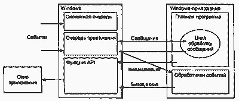

Рис. 14.2. Структура Windows-приложения

Среда Visual Studio.NET содержит удобные средства разработки Windows-при- ложений, выполняющие вместо программиста рутинную работу - создание шаблонов приложения и форм, заготовок обработчиков событий, организацию цикла обработки сообщений и т. д. Рассмотрим эти средства.

Стр. 313

# Шаблон Windows-приложения

Создадим новый проект (File » New » Project), выбрав шаблон Windows Application (рис. 14.3). После более длительных раздумий, чем для консольного приложе. пия, среда сформирует шаблон Windows-приложения. Первое отличие, которое бросается в глаза, - вкладка заготовки формы Form1.cs$[$Design$]$, расположенная в основной части экрана. Форма представляет собой окно и предназначена для размещения компонентов (элементов управления) - меню, текста, кнопок, списков, изображений и т. д.

[figure not shown]

Рис. 14.3. Выбор шаблона проекта

Среда создает не только заготовку формы, но и шаблон текста приложения. Перейти к нему можно, щелкнув в окне Solution Explorer (View » Solution Explorer) правой кнопкой мыши на файле Form1.cs и выбрав в контекстном меню команду View Code. При этом откроется вкладка с кодом формы, который, за исключением комментариев, приведен в листинге 14.1. Представлять себе, что написано в вашей программе, весьма полезно, поэтому давайте внимательно рассмотрим этот текст.

Листинг 14.1. Шаблон Windows-приложения

```
using System;
using System.Drawing;
using System.Collections;
using System.ComponentModel;
using System.Windows.Forms;
using System.Data;
```

Стр. 314

```
namespase WindowsApplicationl;
{
    public class Forml: System.Windows.Forms.Form
    {
        private System.ComponentModel.Container components = null;
        public Forml() { InitializeComponent(); }
        protected override void Dispose( bool disposing )
        {
            if( disposing )
            {
                if(components != null) { components.Dispose(); }
            }
            base.Dispose( disposing );
        }
```

```
    #region kindows Form Designer generated code
        private void InitializeComponent()
        {
            this.components = new System.ComponentModel.Container():
            this.Size = new System.Drawing.Size(300.300);
            this.Text = "Forel";
        }
    #endregion
        static void Main()
        { Application.Run(new Forml()); }
    }
}
```

Приложение начинается с директив использования пространств имен библиоте- NET. Для нустой формы, не содержащей ни одного компонента, необходимыми являются только две директивы:

```
using System;
using System.Windows.Forms;
```

Остальные директивы добанлены средой «на вырост». С пространством имен te вы уже знакомы. Пространство System.Windows.Forms содержит огромное малчество типов, являющихся строительными блоками Windows-приложений. Список наиболее употребительных элементов этого пространства имен приведен в табл. 14.1, а часть нерархии - на рис. 14.4.

Стр. 315

Таблица 14.1. Основные типы Windows.Forms

- Класс - Назначение
- Application - Класс Windows-приложения, При помощи методов этого класса можно обрабатывать Windows-сообщения, запускать и прекращать работу приложения и т. п.
- ButtonBase, Button, CheckBox, ComboBox, DataGrid, GroupBox, ListBox, LinkLabel, PictureBox - Примеры классов, представляющих элементы управления (компоненты): базовый класс кнопок, кнопка, флажок, комбинированный список, таблица, группа, список, метка с гиперссылкой, изображение
- Form - Класс формы - окно Windows-приложения
- ColorDialog, FileDialog, FontDialog, PrintPreviewDialog - Примеры стандартных диалоговых окон для выбора цветов, файлов, шрифтов, окно предварительного просмотра
- Menu, MainMenu, MenuItem, ContextMenu - Классы выпадающих и контекстных меню
- Clipboard, Help, Timer, Screen, ToolTip, Cursors - Вспомогательные типы для организации графических интерфейсов: буфер обмена, помощь, таймер, экран, подсказка, указатели мыши
- StatusBar, Splitter, ToolBar, ScrollBar - Примеры дополнительных элементов управления, размещаемых на форме: строка состояния, разделитель, панель инструментов и т. д.

Мы будем изучать типы пространства имен Windows.Forms по мере необходимости. Продолжим рассмотрение листинга 14.1. В нем описан класс Forml, производный от класса Form. Он наследует от своего предка множество элементов, которые мы рассмотрим в следующих разделах. В самом классе Forml описано новое закрытое поле components - контейнер для хранения компонентов, которые можно добавить в класс формы. Конструктор формы вызывает закрытый метод InitializeComponent, автоматически формируемый средой (код метода скрыт между директивами препроцессора #region и #endregion). Этот метод обновляется средой при добавлении элементов управления на форму, а также при изменении свойств формы и содержащихся на ней элементов. Например, если изменить цвет фона формы с помощью окна свойств (Properties), в методе появится примерно такая строка:

```
this.BackColor = System.Drawing.SystemColors.AppWorkspace;
```

Метод освобождения ресурсов Dispose вызывается автоматически при закрытии формы. Точка входа в приложение, метод Main, содержит вызов статического метода Run класса Application, Метод Run запускает цикл обработки сообщений и выводит на экран форму, повый экземпляр которой передан ему в качестве параметра.

Стр. 316

- System.Object
  - ListViewItem
  - System.MarshalByRetObject
    - TreeNode
    - System.ComponentModel.Companent
- System.ComponentModel.Companent
  - CommenDialog
    - ColorDialog
    - FileDialog
    - PentDialog
    - PageSetupDialog
    - PrintDialog
  - ErrorPrevider
  - HelpPrevider
  - ImageList
  - Menu
    - ContextMenu
    - MainManu
    - MainItem
  - NotyfiIcon
  - StandartPanel
  - Timer
  - ToolBarButton
  - ToolTip
- System.ComponentModel.Companent
  - Control
    - ButtonBase
      - Button
      - CheckBox
      - RadioButton
    - DataGrid
    - DataTimePicker
    - GroupBpx
    - Label
      - LinkLabel
    - ListControl
      - ComboBox
      - ListBox
        - CheckedListBox
    - ListView
    - MonthCalendar
- System.ComponentModel.Companent
  - Control
    - PictureBox
    - PrintReviewControl
    - ProgressBar
    - ScrollableControl
      - Panel
        - TabPage
      - ContainerControl
        - Form
          - PrintPreviewDialog
          - ThreadExceptionDialog
        - PropertyGrid
        - UserControl
        - UpDownBase
          - DomainUpDown
          - NumericUpDown
- System.ComponentModel.Companent
  - Control
    - ScrollBar
      - HScrollBar
      - VScrollBar
  - Splitter
  - StatusBar
  - TabControl
  - TextBoxBase
    - RichTextBox
    - TextBox
  - ToolBar
  - TrackBar
  - TreeView

Рис. 14.4. Элементы управления Windows.Forms (Который уже в зюзю устарел)

# ПРИМЕЧАНИЕ

Запуск приложения, для создания которого мы пока не написали ни строчки кода. можно выполнить с помощью команды меню Debug » Start или клавищи F5. На экран выводится пустая форма, обладающая стандартиой функциональностью окна Windows-приложения: например, она умеет изменять свои размеры и реагировать на действия с кнопками развертывания и закрытия.

Процесс создания Windows приложения состоит из двух основных этапов:

1. Визуальное проектирование, то есть задание внешнего облика приложения.
2. Определение поведения приложения путем написания процедур обработки событий.

Визуальное проектирование заключается в помещении на форму компонентов (элементов управления) и задании их свойств и свойств самой формы с помошью окна свойств, Если его не видно, можно воспользоваться командой меню View > Properties Window, Свойства отображаются либо в алфавитном порядке, либо сгруппированными по категориям. Способ отображения выбирается с помощью кнопок, расположенных в верхней части окна свойств (рис. 14.5).

Стр. 317

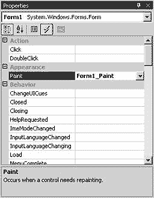

Рис. 14.5. Окно свойств

Самый простой способ размещения компонента - двойной щелчок на соответствующем значке палитры компонентов Toolbox (если ее не видно, можно воспользоваться командой меню View » Toolbox), при этом компонент помещается на форму. Затем компонент можно переместить и изменить его размеры с помощью мыши. Можно также сделать один щелчок на палитре и еще один щелчок в том месте формы, где планируется разместить компонент. В окне свойств отображаются свойства выбранного в данный момент компонента (он окружен рамкой).

Задание свойств выполняется либо выбором имеющихся в списке вариантов, либо вводом требуемого значения с клавиатуры. Если около имени свойства стоит значок +, это означает, что свойство содержит другие свойства. Они становятся доступными после щелчка на значке. Пример формы, на которой размещены компоненты с вкладки палитры Windows Forms, показан на рис. 14.6. Эти компоненты описаны в разделе «Элементы управления» (см. с. 325).

Определение поведения программы начинается с принятия решений, какие действия должны выполияться при щелчке на кнопках, вводе текста, выборе пунктов меню и т. д., иными словами, по каким событиям будут выполняться действня. реализующие функциональность программы.

Стр. 318

- Form1 _0x
- textBox1
- button1

Рис. 14.6. Форма с размещенными на ней компонентами

# ВНИМАНИЕ

Интерфейс программы должен быть интуитивно понятным и по возможности простым. Часто повторяющиеся действия не должны требовать от пользователя выполнения сложных последовательностей операций.

Заготовка шаблона обработчика события формируется двойным щелчком на поле, расположенном справа от имени соответствующего события на вкладке Events окна свойств, при этом появляется вкладка окна редактора кода с заготовкой соответствующего обработчика (вкладка Events отображается в окне свойств при щелчке на кнопке с желтой молнией, как показано на рис. 14.5).

Для каждого класса определен свой набор событий, на которые он может реагировать. Наиболее часто используемые события:

- Activated - получение формой фокуса ввода;
- Click, DoubleClick - одинарный и двойной щелчки мышью;
- Closed - закрытие формы;
- Load - загрузка формы;
- KeyDown, KeyUp - нажатие и отпускание любой клавиши и их сочетаний;
- KeyPress - нажатие клавиши, имеющей ASCII-код;
- MouseDown, MouseUp - нажатие и отпускание кнопки мыши;
- MouseMove - перемещение мыши;
- Paint - возиикает при необходимости прорисовки формы.

В листинге 14.2 приведен текст программы, сформированной средой после размещения на форме компонентов, представленных на рис, 14.6, и выбора для кнопки события Click, а для поля ввода - события KeyPress, Из листинга для удобства восприятия удалены лишние элементы.

Стр. 319

Листинг 14.2. Шаблон приложения с двумя компонентами и заготовками обработчиков событий

```
using System;
using System.Drawing;
using System.Collections;
using System.ComponentModel;
using System.Windows.Forms;
using System.Data;
namespace windowsApplicationl
{
    public class Forml : System.Windows.Forms.Form
    {
        private System.Windows.Forms,TextBox textBox1;              // 0
        private System.Windows.Forms.Button buttonl;                // 1
        private System.ComponentModel.Container components = null;  // 2
        public Form1() { InitializeComponent(); }
        protected override void Dispose( bool disposing ) { ... }
```

```
        #region Windows Form Designer generated code
        private void InitializeComponent()
        {
            this.textBox1 = new System.Windows.Forms.TextBox();  // 3
            this.buttonl = new System.Windows.Forms.Button();    // 4
            this.SuspendLayout();                                // 5
            //
            // textBox1
            //
            this.textBoxl.Location = new System.Drawing.Point(24. 16):
            this.textBox1.Name = "textBox1";
            this.textBox1.Size = new System.Drawing.Size(240, 20);
            this.textBox1.TabIndex = 0:
            this.textBox1.Text = "textBox1":
            this.textBoxl.KeyPress += new // б
            System.Windows.Forms.KeyPressEventHandler(this.textBoxl_KeyPress);
```

```
            //
            // button1
            //
            this.buttonl.Location = new System.Drawing.Point(192, 80);
            this.buttonl.Name = "button1";
            this.buttonl.TabIndex = 1;
            this.buttonl.Text = "button1";
            this.buttonl.Click += new  // 7
            System.EventHandler(this.button1 Click);
            //
            // Form1
            //
            this.AutoScaleBaseSize = new System.Drawing.Size(5, 13);
            this.ClientSize = new System.Drawing.Size(292, 126);
            thisControls.Add(this.buttonl);  // 8
```

Стр. 320

```
            this.Controls.Add(this.textBoxl);  // 9
            this.Name = "Forml";
            this.Text = "Forml";
            this.Resumelayout(false);          // 10
        }
        #endregion
        static void Main()
        { Apolication, Run(new Forml()); }
        private void buttonl_Click(object serder, System EvertArgs e) { ... } // 11
        private void textBox1_KeyPress(object sender. Syster, Windows, Forms KeyPressEventArgs e) { ... } //12
    }
}
```

```
public class Forml : Form  // 0
{
    private TextBox textBox1;  // 1
    private Button buttonl;    // 2
    private Container components = null;
}
```

Чаше всего программист изменяет имена, присваиваемые элементам средой, более осмысленными. Это можно сделать, задав новое значение свойства Name элемента.

# ПРИМЕЧАНИЕ

Того же самого эффекта можно достичь и с помощью вкладки Class View (View Class View), выбрав в списке нужный элемент и изменив значение его свойства Name в окне свойств. Обратите внимание на то, что при этом в нем отображаются свойства кнопки button1 не как элемента интерфейса, а как поля класса. Можно изменить имена и вручную, но это более трудоемко и чревато ошибками.

Стр. 321

Самое важное происходит в методе InitializeComponent. В операторах 3 и 4 создаются экземпляры компонентов, затем для каждого из них задаются свойства, определяющие их положение, размер, вид и т. д. Обратите внимание на операторы 6 и 7, В них регистрируются обработчики соответствующих событий, Механизм обработки событий тот же, что мы рассматривали в главе 10 (см. с. 232) - он описывается моделью «публикация - подписка». Например, для кнопки button1, в составе которой есть событие Click, регистрируется обработчик button1_Click, являющийся закрытым методом класса Forml. Это значит, что при наступлении события нажатия на кнопку (об этом сообщит операционная система) будет вызван соответствующий обработчик. Имя обработчика формируется средой автоматически из имени экземпляра компонента и имени события. Обратите внимание на то, что обработчикам передаются два параметра: объект-источник события и запись, соответствующая типу события.

# ПРИМЕЧАНИЕ

При задапии обработчика можно задать и другое имя, для этого оно записывается справа от имени соответствующего события на вкладке Events окна свойств.

После создания экземпляров компонентов и настройки их свойств компоненты заносятся в коллекцию, доступ к которой выполняется через свойство Controls (операторы 8 и 9). Если этого не сделать, компоненты не будут отображаться на форме. Коллекция поддерживает методы добавления и удаления компонентов (Add и Remove).

Таким образом, для размещения компонента на форме необходимо выполнить три действия:

1. Создать экземпляр соответствующего класса.
2. Настроить свойства экземпляра, в том числе зарегистрировать обработчик событий.
3. Поместить экземпляр в коллекцию компонентов формы.

Операторы 5 и 10 используются для того, чтобы все изменения в свойства элементов вносились одновременно. Для этого в операторе 5 внесение изменений «замораживается», а в операторе 10 разрешается. В теле обработчиков событий (операторы 11 и 12) программист может наконецто самостоятельно написать код, который будет выполияться при наступленни события. Добавим в эти строки операторы, выводящие окна сообщений с соответствующим текстом:

```
MessageBox, Show("Нажата кнопка button1");        // 11
MessageBox, Show("Нажата клавиша " + e, KeyChar); // 12
```

Здесь используется простейший вариант статического метода Show класса MessageBox, определенного в пространстве имен System, Windows. Forms, Существуют более десяти перегруженных вариантов этого метода, позволяющих варьировать вид выво- димой информации, например задать заголовок окна и наименования отображаемых на нем кнопок. Прежде чем приступить к изучению форм и элементов управления, размещаемых на формах, необходимо рассмотреть их общего предка - класс Control.

Стр. 322

# Класс Control

Класс Contro1 является базовым для всех отображаемых элементов, то есть элементов, которые составляют графический интерфейс пользователя, например кнопок, списков, полей ввода и форм. Класс Control реализует базовую функциональность интерфейсных элементов. Он содержит методы обработки ввода пользователя с помощью мыши и клавиатуры, определяет размер, положение, цвет фона и другие характеристики элемента. Для каждого объекта можно определить родительский класс, задав свойство Parent, при этом объект будет иметь, например, такой же цвет фона, как и его родитель. Речь идет не о наследовании, а о взаимоотношениях объектов во время выполнения программы. Например, если на форме размещена кнопка, форма является родительским объектом по отношению к кнопке. Наиболее важные свойства класса Control перечислены в табл. 14.2, методы - в табл. 14.3.

Таблица 14.2. Основные свойства класса Control

- Свойство - Описание -
- Anchor - Определяет, какие края элемента управления будут привязаны к краям родительского контейнера. Если задать привязку всех краев, элемент будет изменять размеры вместе с родительским
- BackColor, Background Image, Font, ForeColor, Cursor - Определяют параметры отображения рабочей области формы: цвет фона, фоновый рисунок, шрифт, цвет текста, вид указателя мыши
- Bottom, Right - Координаты нижнего правого угла элемента. Могут устанавливаться также через свойство Size
- Top, Left - Координаты верхнего левого угла элемента. Эквивалентны свойству Location
- Bounds - Возвращает объект типа Rectangle (прямоугольник), который определяет размеры элемента управления
- ClientRectangle - Возвращает объект Rectangle, определяющий размеры рабочей области элемента
- ContextMenu - Определяет, какое контекстное меню будет выводиться при щелчке на элементе правой кнопкой мыши
- Dock - Определяет, у какого края родительского контейнера будет отображаться элемент управления
- Location - Координаты верхнего левого угла элемента относительно верхнего левого угла контейнера, содержащего этот элемент, в виде структуры типа Point. Структура содержит свойства Х и Y
- Height, Width - Высота и ширина элемента
- Size - Высота и ширина элемента в виде структуры типа Size. Структура содержит свойства Height и Width

Стр. 323

Таблица 14.2 (продолжение)

- Свойство - Описание -
- Created, Disposed, Enabled, Focused, Visible - Возвращают значения типа bool, определяющие текущее состояние алемента: создан, удален, использование разрещено, имест фокус ввода, видимый
- Handle - Возвращает дескриптор элемента (уникальное целочисленное значение, сопоставленное элементу)
- ModifierKeys - Статическое свойство, используемое для проверки состояния модифицирующих клавиш (Shift, Control, Alt). Возвращает результат в виде объекта типа Keys
- MouseButtons - Статическое свойство, проверяющее состояние клавиш мыши. Возвращает результат в виде объекта типа MouseButtons
- Opacity - Определяет степень прозрачности элемента управления. Может изменяться от 0 (прозрачный) до 1 (непрозрачный)
- Parent - Возвращает объект, родительский по отношению к данному (имеется в виду не базовый класс, а объект-владелец)
- Region - Определяет объект Region, при помощи которого можно управлять очертаниями и границами элемента управления
- TabIndex, TabStop - Используются для настройки последовательности перемещения с помощью клавиши Tab по элементам управления, расположенным на форме

Таблица 14.3. Основные методы класса Control

- Метод - Описание
- Focus - Установка фокуса ввода на элемент
- GetStyle, SetStyle - Получение и установка флагов управления стилем элемента. Используются значения перечисления ControlStyles (см. далее)
- Hide, Show - Управление свойством Visible (Hide - скрыть элемент, Show - отобразить элемент)
- Invalidate - Обновление изображения элемента путем отправки соответствующего сообщения в очередь сообщений. Метод перегружен таким образом, чтобы можно было обновлять не всю область, запимаемую элементом, а лишь ее часть
- 0nXXXX - Методы-обработчики событий (OnMouseMove, OnkeyDown, OnResize, OnPaint и т. п.), которые могут быть замещены в производных классах
- Refresh - Обновление элемента и всех его дочерних элементов
- SetBounds, SetLocation, SetClientArea - Управление размером и положением элемента

Стр. 324

Перечисление ControlStyles задает возможные значения стиля формы и ниде битовых флагов, поэтому можно использовать их комбинации. Значения исех констант перечисления можно посмотреть в электронной документации, а для первого знакомства достаточно одного - Res izeRedraw, Этот стиль определяет, что при изменении размеров формы она будет автоматически перерисована. По умолчанию перерисовка не выполняется, и если на форме есть какое-либо изображение, результат изменеция размеров формы может сильно озадачить. В табл. 14.4 перечислена небольшая часть событий, определенных в классе Control.

Таблица 14.4. Некоторые события класса Control

- Событие - Описание
- Click, DoubleClick, MouseEnter, MouseLeave, MouseDown, MouseUp, MouseMove, Mousewheel - События от мыши
- KeyPress, KeyUp, KeyDown - События от клавиатуры
- BackColorChanged, ContextMenuChanged, FontChanged, Move, Paint, Resize - События изменения элемента
- GotFocus, Leave, LostFocus - События получения и потери фокуса ввода

Применение наиболее важных элементов, описанных в таблицах, рассматривается в следующих разделах. При написании приложений применяются два способа обработки событий:

- замещение стандартного обработчика;
- задание собственного обработчика.

В большинстве случаев применяется второй способ. Среда разработки создает заготовку обработчика по двойному щелчку на поле, расположенном справа от имени соответствующего события на вкладке Events окна свойств. При этом в код приложения автоматически добавляется строка, регистрирующая этот обработчик. Первый способ, то есть переопределение виртуальных методов 0nXXXX (OnMouseMove, OnKeyDown, OnResize, OnPaint и т. il.), применяется в основном тогда, когда перед реакцией на событие требуется выполнить какие-либо дополнительные действия. За подробностями интересующиеся могут обратиться к $[$27$]$.

# Элементы управления

Элементы управления, или компоненты, помещают на форму с помощью панели инструментов ToolBox (View ToolBox). В этом разделе кратко описаны простейшие компоненты и приведены примеры их использования. Обычно компоненты применяют в диалоговых окнах для получения данных от пользователя или его информирования.

# Метка Label

Метка предназначена для размещения текста на форме. Текст хранится в свойстве Text. Можно задавать шрифт (свойство Font), цвет фона (BackColor), цвет шрифта (ForeColor) и выравнивание (TextAlign) текста метки. Метка может автоматически изменять размер в зависимости от длины текста (AutoSize - True), Можно разместить на метке изображение (Image) и задать прозрачность (установить для свойства BackColor значение Color,Transparent). Метка не может получить фокус ввода, следовательно, не обрабатывает сообщения от клавиатуры. Пример использования меток приведеп далее (см. с. 327).

Стр. 325

# Кнопка Button

Основное событие, обрабатываемое кнопкой, - щелчок мышью (C1ick). Кроме того, кнопка может реагировать на множество других событий - нажатие клавиш на клавиатуре и мыши, изменение параметров и т. д. Нажатие клавиши Enter или пробела, если при этом кнопка имеет фокус ввода, эквивалентно щелчку мышью на кнопке. Можно изменить начертание и размер шрифта текста кнопки, который хранится в свойстве Text, задать цвет фона и фоновое изображение так же, как и для метки. Если занести имя кнопки в свойство AcceptButton формы, на которой расположена кнопка, то нажатие клавиши Enter вызывает событие Click, даже если кнопка не имеет фокуса ввода. Такая кнопка имеет дополнительную рамку и называется кнопкой по умолчанию.

Аналогично, если занести имя кнопки в свойство CancelButton формы, на которой расположена кнопка, то нажатие клавиши Esc вызывает событие Click для этой кнопки. Кнопки часто используются в диалоговых окнах. Как видно из названия, такое окно предназначено для диалога с пользователем и запрашивает у него какиелибо сведения (например, какой выбрать режим или какой файл открыть). Диалоговое окно обладает свойством модальности. Это означает, что дальнейшие действия с приложением невозможны до того момента, пока это окно не будет закрыто. Закрыть окно можно, либо подтвердив введенную в него информацию щелчком на кнопке OK (или Yes), либо отменив ее с помощью кнопки закрытия окна или, например, кнопки Cancel.

Таблица 14.5. Значения перечисления DialogResult

- Значение - Описание
- None - Окно не закрывается
- OK - Нажата кнопка ОК
- Cancel - Нажата кнопка Cancel
- Abort - Нажата кнопка Abort
- Значение - Описанне
- Ignore - Нажата кнопка Ignore
- Yes - Нажата кнопка Yes
- No - Нажата кнопка No
- Retry - Нажата кнопка Retry

Для сохранения информации о том, как было закрыто окно, у кнопки определяют свойство DialogResult. Это свойство может принимать стандартные значения из перечисления DialogResult, определенного в пространстве имен SystemWindows Forms. Значения перечисления приведены в табл. 14.5. Пример использования кнопок приведен в следующем разделе.

Стр. 326

# Поле ввода TextBox

Компонент TextBox позволяет пользователю вводить и редактировать текст, который запоминается в свойстве Text. Можно вводить строки практически неограниченной длины (приблизительно до 32 000 символов), корректировать их, а также вводить защищенный текст (пароль) путем установки маски, отображаемой вместо вводимых символов (свойство PasswordChar). Для обеспечения возможности ввода нескольких строк устанавливают свойства Multiline, ScrollBars и WordWrap. Доступ только для чтения устанавливается с помощью свойства ReadOnly. Элемент содержит методы очистки (Clear), выделения (Select), копирования в буфер (Cоpy), вставки из него (Paste) и др., а также реагирует на множество событий, основными из которых являются KeyPress и KeyDown. Рассмотрим создание простого приложения, в котором использованы компоненты типа Labe1, Button и TextBox. Главное окно приложения показано на рис. 14.7.

- Диагностика кармы _OX
- Введите число : __

Рис. 14.7. Окно приложения «Диагностика кармы»

Пользователь вводит число и нажимает клавишу Enter, после чего введенное значение сравнивается с числом, «задуманным» генератором случайных чисел. Если пользователь не угадал, выводится сообщение «Не угадали!». Каждое следующее сообщение для наглядности немного сдвигается вправо относительно предыдущего. После совпадения выводится итоговое сообщение, и фокус ввода передается на кнопку Еще раз (рис, 14.8). «Коэффициент невезучести» определяется как количество попыток, деленное на максимально возможное значение числа. Создание приложения начинается с проектирования его интерфейса. На форме располагаются метки, поля ввода и кнопка. В окне свойств их свойству Text задается перечисленные в табл. 14.6 значения (в окне отображаются свойства выделенного элемента; элемент выделяется щелчком мыши).

Стр. 327

- Диагностика кармы _OX
- Введите число : *0*
- Коэффициент невезучести : *0,6*
- Еще раз

Рис. 14.8. Окно приложения после ввода правильного ответа

Таблица 14.6. Значение свойства Text для компонентов приложения

- Компонент - Значение свойства Text
- Forml - Диагностика кармы
- Tabel1 - Введите число
- labe12, labe13, textBox1 - Пустое значение
- buttonl - Еще раз

Необходимо стереть значение, заданное по умолчанию.

Стр. 328

Поведение приложения задается в обработчиках событий. Число надо загадывать до того, как пользователь введет первый ответ, а затем после каждого щелчка на кнопке Еще раз. Следовательно, эти действия должны выполняться при загрузке формы (событие Load) и щелчке на кнопке (событие Click). Ответ пользователя анализируется при нажатии клавиши Enter после ввода числа (событие KeyPress элемента textBox1). Вызов редактора программ выполняется двойным щелчком рядом с соответствующим событием элемента на вкладке Events окна свойств (см. рис. 14.5). Для хранения загаданного числа и ответа пользователя применяются поля і и k. В константе mах хранится максимально возможное число. Переменная rnd представляет собой экземпляр генератора случайных чисел. Класс Random описан в одноименном разделе (см. с. 148). Сокращенный текст программы с комментариями приведен в листинге 14.3.

Листинг 14.3. Программа «Угадай число»

```
using System;
using System.Drawing;
using System.Collections;
using System.ComponentModel;
using System.Windows.Forms;
using System.Data;
```

```
namespace WindowsApplication1
{
    public class Forml : Form
    {
        private Label label1;
        private TextBox textBox1;
        private Button buttonl;
        private Label label2;
        private Label label3;
        private Container components = null;

        public Forml() { ...}
        protected override void Dispose( bool disposing ){ ... }
        Windows Form Designer generated code { … }
        const int max = 10; // максимальное значение загадываемого числа
        Random rnd; // экземпляр генератора случайных чисел
        int 1, k; // загадка и отгадка
```

```
        static void Main() { … }
        private void Forml_Load(object sender, EventArgs e)
        {
            rnd = new Random();
            i = rnd.Next(max); // загадано число в диапазоне от 0 до max
        }
```

```
        private void textBox1_KeyPress(object sender, KeyPressEventArgs e)
        {
            int n;
            if ( e.KeyChar != (char)13 )
                return; // если нажата не клавиша Enter, выйти
            try  // преобразование ввода пользователя в число
            {
                n = Convert. ToInt32(textBox1.Text);
            }
            catch
            {
                n=-1; // если введено не число, принять за неверный ответ
            }
```

```
            if(n!=i)// ========== пользователь не угадал
            {
                labe12.Left += 5;
                labe12.Text = "He угадали!";
                textBox1.Clear();
                k++;  // увеличение счетчика попыток
                buttonl.Visible = false;
            }
```

Стр. 329

```
            else // ========== пользователь угадал
            {
                label2.Left = 32; // восстановить начальное положение метки
                label2.Text = "Коэффициент невезучести";
                double koef = 1.0 * k / max;
                label3.Text = koef.ToString();
                buttonl.Visible = true;
            }
        }
        private void button1_Click(object sender, System.EventArgs e)
        {
            i = rnd.Next(max); // загадано число в диапазоне от 0 до max
            k = 0; // обнуление количества попыток ответа
            textBox1.Clear(); // поле ввода очищено
            textBoxl.Focus(); // курсор установлен на поле ввода
            labe12.Text = "";
            labe13.Text = ""; // метки очищены
        }
    }
}
```

# Меню MainMenu и ContextMenu

Главное меню MainMenu размещается на форме таким же образом, как и другие компоненты: двойным щелчком на его значке на панели Toolbox. При этом значок располагается под заготовкой формы, а среда переходит в режим редактирования пунктов меню. Каждый пункт меню представляет собой объект типа MenuItem, и при вводе пункта меню мы задаем его свойство Text. Переход к заданию заголовка следующего пункта меню выполняется либо щелчком мыши, либо нажатием клавиши Enter и клавиш со стрелками. Обычно, чтобы сделать программу понятнее, изменяют также свойства Name каждого пункта так, чтобы они соответствовали названиям пунктов. Пункт меню может быть запрещен или разрешен (свойство Enabled), видим или невидим (Visible), отмечен или не отмечен (Checked). Заготовка обработчика событий формируется двойным щелчком на пункте меню. Любое приложение обычно содержит в меню команду Exit, при выборе которой приложение завершается. Для закрытия приложения можно воспользоваться либо методом Close класса главной формы приложения, либо методом Exit класса Application, например:

```
private void Exit Click(object sender, EventArgs e)
{
    // имя пункта меню - Exit
    Close();
    // или:
    // Application.Exit();
}
```

Стр. 330

Контекстное меню - это меню, которые вызывается во время выполнения программы по нажатию правой кнопки мыши па форме или элементе управления. Обычно в этом меню размещаются пункты, дублирующие пункты главного меню, или пункты, определяющие специфические для данного компонента действия. Контекстное меню ContextMenu создается и используется аналогично главному (значок контекстного меню появляется на папели инструментов, если воспользоваться кнопкой прокрутки). Для привязки контекстного меню к компоненту следует установить значение свойства ContextMenu этого компонента равным имени контекстного меню.

# Флажок CheckBox

Флажок используется для включения-выключения пользователем какого-либо режима. Для проверки, установлен ли флажок, анализируют его свойство Checked, принимающее значение true или false. Флажок может иметь и третье состояние - «установлен, но не полностью». Как правило, это происходит в тех случаях, когда устанавливаемый режим определяется несколькими «подрежимами», часть из которых включена, а часть выключена. В этом случае используют свойство CheckState, которое может принимать значения Checked, Unchecked и Intermediate.

Кроме того, флажок обладает свойством ThreeState, которое управляет возможностью установки третьего состояния пользователем с помощью мыши. Для флажка можно задать цвет фона и фоновое изображение так же, как и для метки. Свойство Аppearance управляет отображением флажка: либо в виде собственно флажка (Normal), либо в виде кнопки (Button), которая «залипает» при щелчке на ней мышью.

Флажки используются в диалоговых окнах как поодиночке, так и в группе, причем все флажки устанавливаются независимо друг от друга. Пример приложения с флажками приведен далее в этой главе.

# Переключатель RadioButton

Переключатель позволяет пользователю выбрать один из нескольких предложенных вариантов, поэтому переключатели обычно объединяют в группы. Если один из них устанавливается (свойство Checked), остальные автоматически сбрасываются. Программист может менять стиль и цвет текста, связанного с переключателем, и его выравнивание. Для переключателя можно задать цвет фона и фоновое изображение так же, как и для метки.

Переключатели можно поместить непосредственно на форму, в этом случае все они составят одну группу. Если на форме требуется отобразить несколько групп переклчателей, их размещают внутри компонента Group или Pane1. Свойство Appearance управляет отображением переключателя: либо в традиционном виде (Normal), либо в виде кнопки (Button), которая «залипает» при щелчке на ней мышью. При установке для свойства AutoCheck значения false кнопка не «залипает». Пример использования переключателей приведен далее в этой главе.

Стр. 331

# Панель GroupBox

Панель GroupBox служит для группировки элементов на форме, например для того, чтобы дать общее название и визуально выделить песколько переключателей или флажков, обеспечивающих выбор связанных между собой режимов. Приведенная в листинге 14.4 программа запрашивает у пользователя, массив какой длины он хочет создать, и создает целочисленный массив с помощью генератора случайных чисел. Пользователь может выбрать диапазон значений элементов: либо $[$-10; 10$]$, либо $[$-100; 100$]$. После создания массива можно вычислить его максимальный элемент и/или количество положительных элементов. Окно приложения показано на рис. 14.9. Для удобства имена (свойство Name) большинства компонентов изменены, как указано на рисунке. Переключатели размещены на нанели типа GroupBox, Установлено свойство Checked компонента radioButtonl, очищены все поля ввода, а для полей maxtextBox и numPosittextBox установлено свойство ReadOnly (только для чтения).

- Вычисления в массиве _OX
- Количество элементов:
- Значения элементов : [x]$[$-10;10$]$ [o]$[$-100;100$]$
- Создать массив.
- [o] Максимум
- [o] Количество положительных
- Вычислить

Рис. 14.9. Окно приложения для вычислений в массиве

# ПРИМЕЧАНИЕ

При визуальном проектировании важно размещать компоненты приятным глазу образом. При этом удобно пользоваться командами меню Format, предварительно выделив нужные компоненты, «обводя» их мышью или выделяя мышью при нажатой клавише Shift или Ctrl, Например, можно выровнять компоненты по левому краю, выделив их и воспользовавшись командой меню Format » Align » Lefts.

Все действия в программе выполняются щелчками на двух кнопках, то есть обрабатываются два события Click.

Листинг 14.4. Вычисления в массиве

```
using System;
using System.Drawing;
using System.Collections;
using System.ComponentModel;
using System.Windows.Forms;
using System.Data;
```

Стр. 332

```
namespace WindowsApplication1
{
    public class Forml : Form
    {
        private Label label1;
        private GroupBox groupBox1;
        private RadioButton radioButtonl;
        private RadioButton radioButton2;
        private TextBox numtextBox;
        private CheckBox numPositcheckBox;
        private Button createbutton;
        private Button calcbutton;
```

```
        private TextBox maxtextBox;
        private TextBox numPosittextBox;
        private TextBox arraytextBox;
        private CheckBox maxcheckBox;
        private Container components = null;
        public Forml() { ... }
        protected override void Dispose( bool disposing )  { ... }
        Windows Form Designer generated code {...}
        int[] arr; // описание массива
        static void Main(){ ... }
```

```
        private void createbutton_Click(object sender, EventArgs e)
        {
            Random rnd = new Random():
            int a = -10, b = 10; // диапазон значений элементов
            if ( radioButton2.Checked )
            { a = -100; b = 100; } // корректировка диапазона
            int n = 0;
            try { n = int.Parse(numtextBox. Text); } // длина массива
            catch
            {
                MessageBox.Show("Введите количество элементов!");
                numtextBox.Clear();
                numtextBox.Focus();
            }
```

Стр. 333

```
            arraytextBox.Clear(); // очистка полей ввода
            maxtextBox.Clear();
            numPosittextBox.Clear();

            if ( n < 0 ) n = -n; // если введено отрицательное число
            arr = new int[n]; // создание массива
            for ( int 1 = 0: 1 < n: ++1 )
            {
                arr[1] = rnd.Next(a, b); // задание элемента массива
                arraytextBox.Text += " "+ arr[1]; // вывод массива
            }
        }
```

```
        private void calcbutton_Click(object sender. EventArgs e)
        {
            int max = arr[0]:
            int numPosit = 0:
            for ( int 1 = 0; 1 < arr.Length; ++i )
            {
                if ( arr[i] > max ) max = arr[i]; // поиск максимума
                if ( arr[i] > 0 ) ++numPosit; // количество положительных
            }
            if ( maxcheckBox.Checked )
                maxtextBox.Text = max. ToString():
            else maxtextBox.Text = " ";
            if ( numPositcheckBox.Checked )
                numPosittextBox.Text = numPosit.ToString();
            else numPosittextBox.Text = " ";
        }
    }
}
```

# Список ListBox

Список служит для представления перечней элементов, в которых пользователь может выбрать одно (свойство SelectionMode равно One) или несколько значений (свойство SelectionMode равно MultiSimple или MultiExtended), Если значение свойства SelectionMode равно MultiSimple, щелчок мышью на элементе выделяет егo или снимает выделение, Значение Mult1Extended позволяет использовать при выделении дианазона строк клавишу Shift, а при добавлении элемента - клавишу Ctri, аналогично проводнику Windows. Запретить выделение можно, установив значение свойства SelectionMode, равное None. Чаще всего используются списки строк, но можно выводить и произвольные изображения. Список может состоять из нескольких столбцов (свойство MultiColumn) и быть отсортированным в алфавитном порядке (Sorted - True). Элементы списка нумеруются с нуля. Они хранятся в свойстве Items, представляющем собой коллекцию. В Items можно добавлять элементы с помощью методов Add, AddRange и Insert. Для удаления элементов служат методы Remove и RemoveAt, удаляющие заданный элемент и элемент по заданному индексу соответственню. Выделенные элементы можно получить с помощью свойств SelectedItems и Selected- Indices, предоставляющих доступ к коллекциям выделенных элементов и их индексов. В листинге 14.5 приведен пример приложения, которое отображает в списке типа ListBox строки, считанные из входного файла, а затем по щелчку на кнопке Запись выводит выделенные пользователем строки в выходной файл. Вид окна приложения приведен на рис. 14. 10.

Стр. 334

- Form1 _OX
- System.Object
- System.MarshalByRefObject
- System.ComponentModel.Component
- System.Windows.Forms.Control
- System.Windows.Forms.ScrollableControl
- System.Windows.Forms.ContainerControl
- System.Windows.Forms.Form
- Запись

Рис. 14.10. Окно приложения для работы со списком строк

Листинг 14.5. Работа со списком строк

```
using System;
using System.IO;
using System.Drawing;
using System.Collections;
using System.ComponentModel:
Using System.Windows.Forms;
using System.Data;
using System.Collections.Specialized;
```

```
namespace WindowsApplicationl
{
    public class Forml : Form
    {
        private ListBox TistBox1;
        private Button button1;
        private Container components = null;

        public Forml() { ... }
        protected override void Dispose( bool disposing) { ... }
        Windows Form Designer generated code { ... }
```

Стр. 335

Листинг 14.5 (продолжение)

```
    static void Main() {
    private void Forml_Load(object sender, EventArgse)
    {
        try
        {
            StreamReader f - new StreamReader( "input.txt" );
            string buf;
            while ( ( buf = f.ReadLine() ) != null ) // чтение из файла
                listBox1.Items.Add(buf); // занесение в список
        }
```

```
        catch ( FileNotFoundException exc )
        {
            MessageBox.Show( exc.Message );
            return;
        }
    }
    private void buttonl_Click(object sender. EventArgs e)
    {
        StreamWriter f = new StreamWriter( "output.txt" );
        foreach ( string item in listBoxl.SelectedItems )
            f.WriteLine(item); // запись в файл
        f.Close();
    }
}
```

На панели инструментов расположено множество компонентов, не рассмотренных в этой книге. Для их изучения следует обратиться к справочной системе .NET. Она организована понятно и единообразно, и даже те, кто не изучал английский язык, смогут при некотором навыке извлечь оттуда необходимую информацию. Но лучше, конечно, хотя бы немного знать английский язык, это полезно само по себе.

# Совет

При изучении компонента рекомендуется следующая последовательность действий. Разместите компопент па форме, выделите его, пажмите клавишу F1 и перейдите по ссылке …overview (обзор). Изучите разделы Remarks и Example, затем перейдите по ссылке …Members (элементы класса), расположенной в верхней части окна. Попытайтесь получить представление о возможностях изучаемого класса, выделив главные из его свойств и открытых методов. После этого можно вернуться к заготовке приложения и начать экспериментировать со свойствами, а затем - с методами класса.

В следующей части этой главы будут коротко описаны основные элементы классов Form и Application, входящих в состав любого приложения.

Стр. 336

# Предварительные замечания о формах

Класс Form наследует от длинной цепочки своих предков множество элементов, определяющих вид и поведение окон различного типа. Генеалогическое древо класса Form выглядит так: Object->MarshalByRefObject->Component->Control->ScrollableControl->ContainerControl.

Окна приложения могут иметь различные вид и назначение. Все окна можно разделить на модальные и немодальные. Модальное окно не позволяет пользователю переключаться на другие окна того же приложения, пока не будет завершена работа с текущим окном1. Как уже отмечалось, в виде модальных обычно оформляют диалоговые окна, требующие от пользователя ввода какой-либо информации. Модальное окно можно закрыть щелчком на кнопке наподобие ОК, подтверждающей введенную информацию, на кнопке закрытия окна или на кнопке вроде Cancel, отменяющей ввод пользователя. Примером модального окна может служить окно сообщений MessageBox, упоминавшееся в разделе «Шаблон Windows-приложения» (см. с. 322).

Особый вид модального окна - системное модальное окно - не позволяет переключаться даже на окна других приложений.

Немодальное окно позволяет переключаться на другие окна того же приложения. Немодальные окна являются, как правило, информационными. Они используются в тех случаях, когда пользователю желательно предоставить свободу выбора - оставлять на экране какую-либо информацию или нет. Каждое приложение содержит одно главное окно. Класс главного окна приложения содержит точку входа в приложение (статический метод Main). При закрытии главного окна приложение завершается.

В случае использования многодокументного интерфейса (Multiple Document Interface, MDI) одно родительское окно может содержать другие окна, называемые дочерними. При закрытии родительского окна дочерние окна закрываются автоматически. Вид окна определяет его функциональность, например, окно с одинарной рамкой не может изменять свои размеры. Рассмотрим наиболее интересных предков класса формы. Их элементы наследуются не только формой, но и другими компонентами, такими как поля ввода или кнопки. Класс MarshalByRef0bject наделяет своих потомков некой особенностью, благодаря которой обращение к ним выполняется по ссылке, то есть локальная кошия объекта не создается.

Класс Component обеспечивает потомков способностью взаимодействовать с контейнером, в котором они расположены. Кроме того, в нем определен метод Dispose, который автоматически вызывается, когда экземпляр класса более не используется, Поэтому для освобождения ресурсов, связанных с приложением, обычно переопределяют этот метод.

Класс Contro1, являющийся предком всех интерфейсных элементов, рассмотрен в этой главе ранее. В классе ScrollableControl определены элементы, позволяющие компоненту иметь горизонтальную и вертикальную полосы прокрутки. Свойства AutoScrol1 и AutoScrol1MinSize обеспечивают автоматическое появление полос прокрутки в тех случаях, когда выводимая информация не помещается в компоненте. Класс ContainerControl обеспечивает своих потомков возможностью управлять размещенными внутри них дочерними компонентами. Например, на форме обычно располагаются несколько кнопок, меток и т. п., а на панели - несколько флажков или переключателей. Свойства и методы класса позволяют установить фокус ввода на элемент или получать информацию о том, какой элемент имеет фокус ввода. а также управлять порядком получения фокуса с помощью свойств TabStop и TabIndex.

Стр. 337

# Класс Form

Класс Form представляет собой заготовку формы, от которой наследуются классы форм приложения. Помимо множества унаследованных элементов, в этом классе определено большое количество собственных элементов, наиболее употребительные из которых приведены в табл. 14.7-14.9.

Таблица 14.7. Некоторые свойства класса Form

- Свойство - Описание
- AcceptButton - Позволяет задать кнопку или получить информацию о кнопке, которая будет активизирована при нажатии пользователем клавиши Enter
- ActiveMDIChild, IsMDIChild, IsMDIContainer - Свойства предназначены для использования в приложениях с многодокументным интерфейсом (MDI)
- AutoScale - Позволяет установить или получить значение, определяющее. будет ли форма автоматически изменять свои размеры, чтобы соответствовать высоте шрифта, используемого на форме, или размерам размещенных на ней компонентов
- FormBorderStyle - Позволяет установить или получить стиль рамки вокруг формы (используются значения перечисления FormBorderStyle)
- Cance1 Button - Позволяет задать кнопку или получить информацию о кнопке. которая будет активизирована при нажатии пользователем клавиши Esc
- ControlBox - Позволяет установить или получить значение, определяющее, будет ли присутствовать стандартная кнопка системного меню в верхием левом углу заголовка формы
- Menu, MergedMenu - Используются для установки или получения информации о меню на форме
- MaximizeBox, MinimizedBox - Определяют, будут ли на форме присутствовать стандартные кнопки восстановления и свертывания в правом верхнем углу заголовка формы

Стр. 338

- Свойство - Описание
- Showinlaskbar - Определяет, будет ли форма отображаться на панели задач Windews
- StartPosition - Позволяет получить или установить зпачение, определяющее исходное положение формы в момент выполнения программы (используются значения перечисления FormStartPosition). Например, для отображения формы в центре экрана устанавливается значение CenterScreen
- WindowState - Определяет состояние отображаемой формы при запуске (используются значения перечисления FormwindowState)

Таблица 14.8. Методы класса Form

- Метод - Описание
- Activate - Активизирует форму и помещает в нее фокус ввода
- Close - Закрывает форму
- CenterToScreen - Помещает форму в центр экрана
- LayoutMDI - Размещает все дочерние формы на родительской в соответствии со значениями перечисления LayoutMDI
- OnResize - Может быть замещен для реагирования на событие Resize
- Show - Отображает форму (унаследовано от Control)
- ShowDialog - Отображает форму как диалоговое окно (подробнее о диалоговых окнах рассказывается в следующем разделе)

Таблица 14.9. Некоторые события класса Form

- Событие - Описание
- Activate - Происходит при активизации формы (когда она выходит в активном приложении на передний план)
- Closed, Closing - Происходят во время закрытия формы
- MOIChi1dActive - Возникает при активизации дочернего окна

Об использовании некоторых элементов, перечисленных в таблицах, рассказывается в следующем разделе.

# Диалоговые окна

В библиотеке .NET нет специального класса для представления диалоговых окон, Вместо этого устанавливаются определенные значения свойств в классе обычной формы. В диалоговом окне можно располагать те же элементы управления, что и на обычной форме. Диалоговое окно характеризуется:

- неизменяемыми размерами (FormBorderStyle FixedDialog);
- отсутствием кнопок восстановления и свертывания в правом верхнем углу заголовка формы (MaximizeBox - False, MinimizedBox = False);
- наличием кнопок наподобие ОК, подтверждающей введенную информацию, и Cancel, отменяющей ввод пользователя, при нажатии которых окно закрывается (AcceptButton = имя_кнопки_OK, CancelButton = имя_кнопки_Cancel);
- установленным значением свойства DialogResult для кнопок, при нажатии которых окно закрывается.

Стр. 339

Для отображения диалогового окна используется метод ShowDialog, который формирует результат выполнения из значений перечисления DialogResult, описанных в табл. 14.5. Если пользователь закрыл диалоговое окно щелчком на кнопке наподобие ОК, введенную им информацию можно использовать в дальнейшей работе. Закрытие окна щелчком на кнопке вроде Cancel отменяет все введенные данные. Диалоговое окно обычно появляется при выборе пользователем некоторой команды меню на главной форме. Приведем пример простого приложения, содержащего две формы. На главной форме (рис. 14.11) расположено меню из двух команд - Dialog и Exit. При выборе команды Dialog появляется диалоговое окно, включающее метку Введите информацию, поле ввода текста и две кнопки, OK и Cancel (рис. 14.12).

- Form1 _OX
- Dialog - Exit
- |

Рис. 14.11. Главное окно приложения с меню и диалоговым окном

- Form2 X
- Введите информацию
- |
- Ok Cancel

Рис. 14.12. Диалоговое окно

Если пользователь введет текст в диалоговое окно и закроет его щелчком на кнопке ОК, этот текст отобразится в поле метки в главном окне. Если диалоговое окно будет закрыто щелчком на кнопке Cancel, поле метки останется неизменным. Добавление в проект второй формы выполняется выбором в меню команды Project » Add Windows Form. Начнем визуальное проектирование с этой формы. Значения свойств компонентов, установленных с помощью окна свойств, перечислены в табл. 14.10.

Стр. 340

Таблица 14.10. Значения свойсте элементов формы

| Элемент | Свойство | Значение |
| --- | --- | --- |
| Метка | Text | Введите информацию |
|  | TextAl1gn | MiddleCenter |
| Поле ввода | Text | Пустое аначение |
| Кнопка | Name | btnok |
|  | DialogResult | OK |
|  | Text | OK |
| Форма | AcceptButton | btnOK |
|  | CancelButton | btnCance1 |
|  | FormBorderStyle | FixedDialog |
|  | MaximizeBox | False |
|  | MinimizeBox | False |
|  | StartPosition | CenterParent |

Пользователь вводит информацию в поле ввода textBox1, которое является закрытым элементом формы. Чтобы получить значение свойства Text поля ввода. добавим в описание класса свойство Info. Это единственное дополнение, которое вносится в шаблон текста класса формы:

```
public class Form2 : Form
{
    private Label label1;
    private TextBox textBoxl;
    private Button btnOK;
    private Button btnCancel;
    private Container components = null;
    public string Info
    {
        get { return textBoxl.Text; }
    }
    ...
}
```

Стр. 341

Визуальное проектирование главной формы еще проще, чем первой, и сводится к размещению главного меню и метки, Для наглядности метка окружена рамкой (BorderStyle - FixedSingle). Вот как выглядят обработчики событий для пунктов меню:

```
private void menulteml Click( object sender, EventArgs e )
{
    Form2 f = new Form2(); // создание экземпляра класса окна
    if (f.ShowDialog() == DialogResult OK ) // отображение окна
        labell.Text = f.Info;
}
private void menultem2_Click( object sender, EventArgs e )
{
    Close(); // закрытие главного окна
}
```

Как видите, для отображения диалогового окна следует создать экземпляр объекта соответствующей формы, а затем вызвать для этого объекта метод ShowO1alog. При подтверждении ввода текст пользователя можно получить с помощью свойства Info, доступного только для чтения. При необходимости передавать информацию не только из диалогового окна, но и в него, можно добавить в описание свойства часть set.

# ПРИМЕЧАНИЕ

Следует различать процесс создания формы - объекта класса Form или его наследника - от процесса вывода формы на экран, Форма, как и любой объект, создается при выполнении операции new с вызовом конструктора. Для вывода формы служит метод Show или ShowDialog класса Form, вызываемый соответствующим объектом. Для скрытия формы используется метод Hide. Фактически, методы Show и Hide изменяют свойство Visible объекта. Разница между скрытием формы методом Hide и се закрытием методом Close состоит в том, что первый из них делает форму невидимой, но не изменяет сам объект, а метод Close делает объект недоступным и закрывает все его ресурсы.